# DATA 609 - HW 6

Betsy Rosalen

November 13, 2021

## Ex. 1

### Use a data set such as `PlantGrowth` in R to calculate three different distance metrics and discuss the results.

Without thinking much about it I calculated the distance using both variables, independent and dependent, (you can see the results below), but then the numbers didn’t really make sense. For the Manhattan distance it is just doubling the difference in the independent variable, `weight`, from one point to another. For the euclidean distance it’s summing the square of the difference in `weight` with the square of the same difference in `weight` and then taking the square root, and the same for minkowski with p=3 except it’s the difference cubed plus the same difference cubed and then the cube root. This really makes no sense. So then I removed the categorical dependent variable and recalculated. All three distance measures are exactly the same and equal to the difference in `weight` in this case, which I think is as it should be…

#### Distance calculated using both the independent and dependent variables

```r
p <- PlantGrowth
p
```

| weight | group |
| --- | --- |
| 4.17 | ctrl |
| 5.58 | ctrl |
| 5.18 | ctrl |
| 6.11 | ctrl |
| 4.50 | ctrl |
| 4.61 | ctrl |
| 5.17 | ctrl |
| 4.53 | ctrl |
| 5.33 | ctrl |
| 5.14 | ctrl |

[output cut: 20 more lines]

```r
p_manhattan <- as.data.frame(as.matrix(dist(p, method = "manhattan")))
rownames(p_manhattan) <- paste0("   ", as.character(c(1:30)))
kbl(p_manhattan) %>%
  kable_minimal(font_size = 10)
```

|  | 1 | 2 | 3 | 4 | 5 | 6 | 7 | 8 | 9 | 10 | 11 | 12 | 13 | 14 | 15 | 16 | 17 | 18 | 19 | 20 | 21 | 22 | 23 | 24 | 25 | 26 | 27 | 28 | 29 | … |
| --- | --- | --- | --- | --- | --- | --- | --- | --- | --- | --- | --- | --- | --- | --- | --- | --- | --- | --- | --- | --- | --- | --- | --- | --- | --- | --- | --- | --- | --- | --- |
| 1 | 0.00 | 2.82 | 2.02 | 3.88 | 0.66 | 0.88 | 2.00 | 0.72 | 2.32 | 1.94 | 1.28 | 0.00 | 0.48 | 1.16 | 3.40 | 0.68 | 3.72 | 1.44 | 0.30 | 1.04 | 4.28 | 1.90 | 2.74 | 2.66 | 2.40 | 2.24 | 1.50 | 3.96 | 3.26 | … |
| 2 | 2.82 | 0.00 | 0.80 | 1.06 | 2.16 | 1.94 | 0.82 | 2.10 | 0.50 | 0.88 | 1.54 | 2.82 | 2.34 | 3.98 | 0.58 | 3.50 | 0.90 | 1.38 | 2.52 | 1.78 | 1.46 | 0.92 | 0.08 | 0.16 | 0.42 | 0.58 | 1.32 | 1.14 | 0.44 | … |
| 3 | 2.02 | 0.80 | 0.00 | 1.86 | 1.36 | 1.14 | 0.02 | 1.30 | 0.30 | 0.08 | 0.74 | 2.02 | 1.54 | 3.18 | 1.38 | 2.70 | 1.70 | 0.58 | 1.72 | 0.98 | 2.26 | 0.12 | 0.72 | 0.64 | 0.38 | 0.22 | 0.52 | 1.94 | 1.24 | … |
| 4 | 3.88 | 1.06 | 1.86 | 0.00 | 3.22 | 3.00 | 1.88 | 3.16 | 1.56 | 1.94 | 2.60 | 3.88 | 3.40 | 5.04 | 0.48 | 4.56 | 0.16 | 2.44 | 3.58 | 2.84 | 0.40 | 1.98 | 1.14 | 1.22 | 1.48 | 1.64 | 2.38 | 0.08 | 0.62 | … |
| 5 | 0.66 | 2.16 | 1.36 | 3.22 | 0.00 | 0.22 | 1.34 | 0.06 | 1.66 | 1.28 | 0.62 | 0.66 | 0.18 | 1.82 | 2.74 | 1.34 | 3.06 | 0.78 | 0.36 | 0.38 | 3.62 | 1.24 | 2.08 | 2.00 | 1.74 | 1.58 | 0.84 | 3.30 | 2.60 | … |
| 6 | 0.88 | 1.94 | 1.14 | 3.00 | 0.22 | 0.00 | 1.12 | 0.16 | 1.44 | 1.06 | 0.40 | 0.88 | 0.40 | 2.04 | 2.52 | 1.56 | 2.84 | 0.56 | 0.58 | 0.16 | 3.40 | 1.02 | 1.86 | 1.78 | 1.52 | 1.36 | 0.62 | 3.08 | 2.38 | … |
| 7 | 2.00 | 0.82 | 0.02 | 1.88 | 1.34 | 1.12 | 0.00 | 1.28 | 0.32 | 0.06 | 0.72 | 2.00 | 1.52 | 3.16 | 1.40 | 2.68 | 1.72 | 0.56 | 1.70 | 0.96 | 2.28 | 0.10 | 0.74 | 0.66 | 0.40 | 0.24 | 0.50 | 1.96 | 1.26 | … |
| 8 | 0.72 | 2.10 | 1.30 | 3.16 | 0.06 | 0.16 | 1.28 | 0.00 | 1.60 | 1.22 | 0.56 | 0.72 | 0.24 | 1.88 | 2.68 | 1.40 | 3.00 | 0.72 | 0.42 | 0.32 | 3.56 | 1.18 | 2.02 | 1.94 | 1.68 | 1.52 | 0.78 | 3.24 | 2.54 | … |
| 9 | 2.32 | 0.50 | 0.30 | 1.56 | 1.66 | 1.44 | 0.32 | 1.60 | 0.00 | 0.38 | 1.04 | 2.32 | 1.84 | 3.48 | 1.08 | 3.00 | 1.40 | 0.88 | 2.02 | 1.28 | 1.96 | 0.42 | 0.42 | 0.34 | 0.08 | 0.08 | 0.82 | 1.64 | 0.94 | … |
| 10 | 1.94 | 0.88 | 0.08 | 1.94 | 1.28 | 1.06 | 0.06 | 1.22 | 0.38 | 0.00 | 0.66 | 1.94 | 1.46 | 3.10 | 1.46 | 2.62 | 1.78 | 0.50 | 1.64 | 0.90 | 2.34 | 0.04 | 0.80 | 0.72 | 0.46 | 0.30 | 0.44 | 2.02 | 1.32 | … |
| 11 | 1.28 | 1.54 | 0.74 | 2.60 | 0.62 | 0.40 | 0.72 | 0.56 | 1.04 | 0.66 | 0.00 | 1.28 | 0.80 | 2.44 | 2.12 | 1.96 | 2.44 | 0.16 | 0.98 | 0.24 | 3.00 | 0.62 | 1.46 | 1.38 | 1.12 | 0.96 | 0.22 | 2.68 | 1.98 | … |
| 12 | 0.00 | 2.82 | 2.02 | 3.88 | 0.66 | 0.88 | 2.00 | 0.72 | 2.32 | 1.94 | 1.28 | 0.00 | 0.48 | 1.16 | 3.40 | 0.68 | 3.72 | 1.44 | 0.30 | 1.04 | 4.28 | 1.90 | 2.74 | 2.66 | 2.40 | 2.24 | 1.50 | 3.96 | 3.26 | … |
| 13 | 0.48 | 2.34 | 1.54 | 3.40 | 0.18 | 0.40 | 1.52 | 0.24 | 1.84 | 1.46 | 0.80 | 0.48 | 0.00 | 1.64 | 2.92 | 1.16 | 3.24 | 0.96 | 0.18 | 0.56 | 3.80 | 1.42 | 2.26 | 2.18 | 1.92 | 1.76 | 1.02 | 3.48 | 2.78 | … |
| 14 | 1.16 | 3.98 | 3.18 | 5.04 | 1.82 | 2.04 | 3.16 | 1.88 | 3.48 | 3.10 | 2.44 | 1.16 | 1.64 | 0.00 | 4.56 | 0.48 | 4.88 | 2.60 | 1.46 | 2.20 | 5.44 | 3.06 | 3.90 | 3.82 | 3.56 | 3.40 | 2.66 | 5.12 | 4.42 | … |
| 15 | 3.40 | 0.58 | 1.38 | 0.48 | 2.74 | 2.52 | 1.40 | 2.68 | 1.08 | 1.46 | 2.12 | 3.40 | 2.92 | 4.56 | 0.00 | 4.08 | 0.32 | 1.96 | 3.10 | 2.36 | 0.88 | 1.50 | 0.66 | 0.74 | 1.00 | 1.16 | 1.90 | 0.56 | 0.14 | … |
| 16 | 0.68 | 3.50 | 2.70 | 4.56 | 1.34 | 1.56 | 2.68 | 1.40 | 3.00 | 2.62 | 1.96 | 0.68 | 1.16 | 0.48 | 4.08 | 0.00 | 4.40 | 2.12 | 0.98 | 1.72 | 4.96 | 2.58 | 3.42 | 3.34 | 3.08 | 2.92 | 2.18 | 4.64 | 3.94 | … |
| 17 | 3.72 | 0.90 | 1.70 | 0.16 | 3.06 | 2.84 | 1.72 | 3.00 | 1.40 | 1.78 | 2.44 | 3.72 | 3.24 | 4.88 | 0.32 | 4.40 | 0.00 | 2.28 | 3.42 | 2.68 | 0.56 | 1.82 | 0.98 | 1.06 | 1.32 | 1.48 | 2.22 | 0.24 | 0.46 | … |
| 18 | 1.44 | 1.38 | 0.58 | 2.44 | 0.78 | 0.56 | 0.56 | 0.72 | 0.88 | 0.50 | 0.16 | 1.44 | 0.96 | 2.60 | 1.96 | 2.12 | 2.28 | 0.00 | 1.14 | 0.40 | 2.84 | 0.46 | 1.30 | 1.22 | 0.96 | 0.80 | 0.06 | 2.52 | 1.82 | … |
| 19 | 0.30 | 2.52 | 1.72 | 3.58 | 0.36 | 0.58 | 1.70 | 0.42 | 2.02 | 1.64 | 0.98 | 0.30 | 0.18 | 1.46 | 3.10 | 0.98 | 3.42 | 1.14 | 0.00 | 0.74 | 3.98 | 1.60 | 2.44 | 2.36 | 2.10 | 1.94 | 1.20 | 3.66 | 2.96 | … |
| 20 | 1.04 | 1.78 | 0.98 | 2.84 | 0.38 | 0.16 | 0.96 | 0.32 | 1.28 | 0.90 | 0.24 | 1.04 | 0.56 | 2.20 | 2.36 | 1.72 | 2.68 | 0.40 | 0.74 | 0.00 | 3.24 | 0.86 | 1.70 | 1.62 | 1.36 | 1.20 | 0.46 | 2.92 | 2.22 | … |
| 21 | 4.28 | 1.46 | 2.26 | 0.40 | 3.62 | 3.40 | 2.28 | 3.56 | 1.96 | 2.34 | 3.00 | 4.28 | 3.80 | 5.44 | 0.88 | 4.96 | 0.56 | 2.84 | 3.98 | 3.24 | 0.00 | 2.38 | 1.54 | 1.62 | 1.88 | 2.04 | 2.78 | 0.32 | 1.02 | … |
| 22 | 1.90 | 0.92 | 0.12 | 1.98 | 1.24 | 1.02 | 0.10 | 1.18 | 0.42 | 0.04 | 0.62 | 1.90 | 1.42 | 3.06 | 1.50 | 2.58 | 1.82 | 0.46 | 1.60 | 0.86 | 2.38 | 0.00 | 0.84 | 0.76 | 0.50 | 0.34 | 0.40 | 2.06 | 1.36 | … |
| 23 | 2.74 | 0.08 | 0.72 | 1.14 | 2.08 | 1.86 | 0.74 | 2.02 | 0.42 | 0.80 | 1.46 | 2.74 | 2.26 | 3.90 | 0.66 | 3.42 | 0.98 | 1.30 | 2.44 | 1.70 | 1.54 | 0.84 | 0.00 | 0.08 | 0.34 | 0.50 | 1.24 | 1.22 | 0.52 | … |
| 24 | 2.66 | 0.16 | 0.64 | 1.22 | 2.00 | 1.78 | 0.66 | 1.94 | 0.34 | 0.72 | 1.38 | 2.66 | 2.18 | 3.82 | 0.74 | 3.34 | 1.06 | 1.22 | 2.36 | 1.62 | 1.62 | 0.76 | 0.08 | 0.00 | 0.26 | 0.42 | 1.16 | 1.30 | 0.60 | … |
| 25 | 2.40 | 0.42 | 0.38 | 1.48 | 1.74 | 1.52 | 0.40 | 1.68 | 0.08 | 0.46 | 1.12 | 2.40 | 1.92 | 3.56 | 1.00 | 3.08 | 1.32 | 0.96 | 2.10 | 1.36 | 1.88 | 0.50 | 0.34 | 0.26 | 0.00 | 0.16 | 0.90 | 1.56 | 0.86 | … |
| 26 | 2.24 | 0.58 | 0.22 | 1.64 | 1.58 | 1.36 | 0.24 | 1.52 | 0.08 | 0.30 | 0.96 | 2.24 | 1.76 | 3.40 | 1.16 | 2.92 | 1.48 | 0.80 | 1.94 | 1.20 | 2.04 | 0.34 | 0.50 | 0.42 | 0.16 | 0.00 | 0.74 | 1.72 | 1.02 | … |
| 27 | 1.50 | 1.32 | 0.52 | 2.38 | 0.84 | 0.62 | 0.50 | 0.78 | 0.82 | 0.44 | 0.22 | 1.50 | 1.02 | 2.66 | 1.90 | 2.18 | 2.22 | 0.06 | 1.20 | 0.46 | 2.78 | 0.40 | 1.24 | 1.16 | 0.90 | 0.74 | 0.00 | 2.46 | 1.76 | … |
| 28 | 3.96 | 1.14 | 1.94 | 0.08 | 3.30 | 3.08 | 1.96 | 3.24 | 1.64 | 2.02 | 2.68 | 3.96 | 3.48 | 5.12 | 0.56 | 4.64 | 0.24 | 2.52 | 3.66 | 2.92 | 0.32 | 2.06 | 1.22 | 1.30 | 1.56 | 1.72 | 2.46 | 0.00 | 0.70 | … |
| 29 | 3.26 | 0.44 | 1.24 | 0.62 | 2.60 | 2.38 | 1.26 | 2.54 | 0.94 | 1.32 | 1.98 | 3.26 | 2.78 | 4.42 | 0.14 | 3.94 | 0.46 | 1.82 | 2.96 | 2.22 | 1.02 | 1.36 | 0.52 | 0.60 | 0.86 | 1.02 | 1.76 | 0.70 | 0.00 | … |
| 30 | 2.18 | 0.64 | 0.16 | 1.70 | 1.52 | 1.30 | 0.18 | 1.46 | 0.14 | 0.24 | 0.90 | 2.18 | 1.70 | 3.34 | 1.22 | 2.86 | 1.54 | 0.74 | 1.88 | 1.14 | 2.10 | 0.28 | 0.56 | 0.48 | 0.22 | 0.06 | 0.68 | 1.78 | 1.08 | … |

```r
p_euclidean <- as.matrix(dist(p, method = "euclidean"))
rownames(p_euclidean) <- paste0("   ", as.character(c(1:30)))
kbl(p_euclidean) %>%
  kable_minimal(font_size = 10)
```

|  | 1 | 2 | 3 | 4 | 5 | 6 | 7 | 8 | 9 | 10 | 11 | 12 | 13 | 14 | 15 | 16 | 17 | 18 | 19 | 20 | 21 | 22 | 23 | 24 | 25 | 26 | 27 | 28 | 29 | … |
| --- | --- | --- | --- | --- | --- | --- | --- | --- | --- | --- | --- | --- | --- | --- | --- | --- | --- | --- | --- | --- | --- | --- | --- | --- | --- | --- | --- | --- | --- | --- |
| 1 | 0.0000 | 1.9940 | 1.4284 | 2.7436 | 0.4667 | 0.6223 | 1.4142 | 0.5091 | 1.6405 | 1.3718 | 0.9051 | 0.0000 | 0.3394 | 0.8202 | 2.4042 | 0.4808 | 2.6304 | 1.0182 | 0.2121 | 0.7354 | 3.0264 | 1.3435 | 1.9375 | 1.8809 | 1.6971 | 1.5839 | 1.0607 | 2.8001 | 2.3052 | … |
| 2 | 1.9940 | 0.0000 | 0.5657 | 0.7495 | 1.5274 | 1.3718 | 0.5798 | 1.4849 | 0.3536 | 0.6223 | 1.0889 | 1.9940 | 1.6546 | 2.8143 | 0.4101 | 2.4749 | 0.6364 | 0.9758 | 1.7819 | 1.2587 | 1.0324 | 0.6505 | 0.0566 | 0.1131 | 0.2970 | 0.4101 | 0.9334 | 0.8061 | 0.3111 | … |
| 3 | 1.4284 | 0.5657 | 0.0000 | 1.3152 | 0.9617 | 0.8061 | 0.0141 | 0.9192 | 0.2121 | 0.0566 | 0.5233 | 1.4284 | 1.0889 | 2.2486 | 0.9758 | 1.9092 | 1.2021 | 0.4101 | 1.2162 | 0.6930 | 1.5981 | 0.0849 | 0.5091 | 0.4525 | 0.2687 | 0.1556 | 0.3677 | 1.3718 | 0.8768 | … |
| 4 | 2.7436 | 0.7495 | 1.3152 | 0.0000 | 2.2769 | 2.1213 | 1.3294 | 2.2345 | 1.1031 | 1.3718 | 1.8385 | 2.7436 | 2.4042 | 3.5638 | 0.3394 | 3.2244 | 0.1131 | 1.7253 | 2.5314 | 2.0082 | 0.2828 | 1.4001 | 0.8061 | 0.8627 | 1.0465 | 1.1597 | 1.6829 | 0.0566 | 0.4384 | … |
| 5 | 0.4667 | 1.5274 | 0.9617 | 2.2769 | 0.0000 | 0.1556 | 0.9475 | 0.0424 | 1.1738 | 0.9051 | 0.4384 | 0.4667 | 0.1273 | 1.2869 | 1.9375 | 0.9475 | 2.1637 | 0.5515 | 0.2546 | 0.2687 | 2.5597 | 0.8768 | 1.4708 | 1.4142 | 1.2304 | 1.1172 | 0.5940 | 2.3335 | 1.8385 | … |
| 6 | 0.6223 | 1.3718 | 0.8061 | 2.1213 | 0.1556 | 0.0000 | 0.7920 | 0.1131 | 1.0182 | 0.7495 | 0.2828 | 0.6223 | 0.2828 | 1.4425 | 1.7819 | 1.1031 | 2.0082 | 0.3960 | 0.4101 | 0.1131 | 2.4042 | 0.7212 | 1.3152 | 1.2587 | 1.0748 | 0.9617 | 0.4384 | 2.1779 | 1.6829 | … |
| 7 | 1.4142 | 0.5798 | 0.0141 | 1.3294 | 0.9475 | 0.7920 | 0.0000 | 0.9051 | 0.2263 | 0.0424 | 0.5091 | 1.4142 | 1.0748 | 2.2345 | 0.9899 | 1.8950 | 1.2162 | 0.3960 | 1.2021 | 0.6788 | 1.6122 | 0.0707 | 0.5233 | 0.4667 | 0.2828 | 0.1697 | 0.3536 | 1.3859 | 0.8910 | … |
| 8 | 0.5091 | 1.4849 | 0.9192 | 2.2345 | 0.0424 | 0.1131 | 0.9051 | 0.0000 | 1.1314 | 0.8627 | 0.3960 | 0.5091 | 0.1697 | 1.3294 | 1.8950 | 0.9899 | 2.1213 | 0.5091 | 0.2970 | 0.2263 | 2.5173 | 0.8344 | 1.4284 | 1.3718 | 1.1879 | 1.0748 | 0.5515 | 2.2910 | 1.7961 | … |
| 9 | 1.6405 | 0.3536 | 0.2121 | 1.1031 | 1.1738 | 1.0182 | 0.2263 | 1.1314 | 0.0000 | 0.2687 | 0.7354 | 1.6405 | 1.3011 | 2.4607 | 0.7637 | 2.1213 | 0.9899 | 0.6223 | 1.4284 | 0.9051 | 1.3859 | 0.2970 | 0.2970 | 0.2404 | 0.0566 | 0.0566 | 0.5798 | 1.1597 | 0.6647 | … |
| 10 | 1.3718 | 0.6223 | 0.0566 | 1.3718 | 0.9051 | 0.7495 | 0.0424 | 0.8627 | 0.2687 | 0.0000 | 0.4667 | 1.3718 | 1.0324 | 2.1920 | 1.0324 | 1.8526 | 1.2587 | 0.3536 | 1.1597 | 0.6364 | 1.6546 | 0.0283 | 0.5657 | 0.5091 | 0.3253 | 0.2121 | 0.3111 | 1.4284 | 0.9334 | … |
| 11 | 0.9051 | 1.0889 | 0.5233 | 1.8385 | 0.4384 | 0.2828 | 0.5091 | 0.3960 | 0.7354 | 0.4667 | 0.0000 | 0.9051 | 0.5657 | 1.7253 | 1.4991 | 1.3859 | 1.7253 | 0.1131 | 0.6930 | 0.1697 | 2.1213 | 0.4384 | 1.0324 | 0.9758 | 0.7920 | 0.6788 | 0.1556 | 1.8950 | 1.4001 | … |
| 12 | 0.0000 | 1.9940 | 1.4284 | 2.7436 | 0.4667 | 0.6223 | 1.4142 | 0.5091 | 1.6405 | 1.3718 | 0.9051 | 0.0000 | 0.3394 | 0.8202 | 2.4042 | 0.4808 | 2.6304 | 1.0182 | 0.2121 | 0.7354 | 3.0264 | 1.3435 | 1.9375 | 1.8809 | 1.6971 | 1.5839 | 1.0607 | 2.8001 | 2.3052 | … |
| 13 | 0.3394 | 1.6546 | 1.0889 | 2.4042 | 0.1273 | 0.2828 | 1.0748 | 0.1697 | 1.3011 | 1.0324 | 0.5657 | 0.3394 | 0.0000 | 1.1597 | 2.0648 | 0.8202 | 2.2910 | 0.6788 | 0.1273 | 0.3960 | 2.6870 | 1.0041 | 1.5981 | 1.5415 | 1.3576 | 1.2445 | 0.7212 | 2.4607 | 1.9658 | … |
| 14 | 0.8202 | 2.8143 | 2.2486 | 3.5638 | 1.2869 | 1.4425 | 2.2345 | 1.3294 | 2.4607 | 2.1920 | 1.7253 | 0.8202 | 1.1597 | 0.0000 | 3.2244 | 0.3394 | 3.4507 | 1.8385 | 1.0324 | 1.5556 | 3.8467 | 2.1637 | 2.7577 | 2.7011 | 2.5173 | 2.4042 | 1.8809 | 3.6204 | 3.1254 | … |
| 15 | 2.4042 | 0.4101 | 0.9758 | 0.3394 | 1.9375 | 1.7819 | 0.9899 | 1.8950 | 0.7637 | 1.0324 | 1.4991 | 2.4042 | 2.0648 | 3.2244 | 0.0000 | 2.8850 | 0.2263 | 1.3859 | 2.1920 | 1.6688 | 0.6223 | 1.0607 | 0.4667 | 0.5233 | 0.7071 | 0.8202 | 1.3435 | 0.3960 | 0.0990 | … |
| 16 | 0.4808 | 2.4749 | 1.9092 | 3.2244 | 0.9475 | 1.1031 | 1.8950 | 0.9899 | 2.1213 | 1.8526 | 1.3859 | 0.4808 | 0.8202 | 0.3394 | 2.8850 | 0.0000 | 3.1113 | 1.4991 | 0.6930 | 1.2162 | 3.5072 | 1.8243 | 2.4183 | 2.3617 | 2.1779 | 2.0648 | 1.5415 | 3.2810 | 2.7860 | … |
| 17 | 2.6304 | 0.6364 | 1.2021 | 0.1131 | 2.1637 | 2.0082 | 1.2162 | 2.1213 | 0.9899 | 1.2587 | 1.7253 | 2.6304 | 2.2910 | 3.4507 | 0.2263 | 3.1113 | 0.0000 | 1.6122 | 2.4183 | 1.8950 | 0.3960 | 1.2869 | 0.6930 | 0.7495 | 0.9334 | 1.0465 | 1.5698 | 0.1697 | 0.3253 | … |
| 18 | 1.0182 | 0.9758 | 0.4101 | 1.7253 | 0.5515 | 0.3960 | 0.3960 | 0.5091 | 0.6223 | 0.3536 | 0.1131 | 1.0182 | 0.6788 | 1.8385 | 1.3859 | 1.4991 | 1.6122 | 0.0000 | 0.8061 | 0.2828 | 2.0082 | 0.3253 | 0.9192 | 0.8627 | 0.6788 | 0.5657 | 0.0424 | 1.7819 | 1.2869 | … |
| 19 | 0.2121 | 1.7819 | 1.2162 | 2.5314 | 0.2546 | 0.4101 | 1.2021 | 0.2970 | 1.4284 | 1.1597 | 0.6930 | 0.2121 | 0.1273 | 1.0324 | 2.1920 | 0.6930 | 2.4183 | 0.8061 | 0.0000 | 0.5233 | 2.8143 | 1.1314 | 1.7253 | 1.6688 | 1.4849 | 1.3718 | 0.8485 | 2.5880 | 2.0930 | … |
| 20 | 0.7354 | 1.2587 | 0.6930 | 2.0082 | 0.2687 | 0.1131 | 0.6788 | 0.2263 | 0.9051 | 0.6364 | 0.1697 | 0.7354 | 0.3960 | 1.5556 | 1.6688 | 1.2162 | 1.8950 | 0.2828 | 0.5233 | 0.0000 | 2.2910 | 0.6081 | 1.2021 | 1.1455 | 0.9617 | 0.8485 | 0.3253 | 2.0648 | 1.5698 | … |
| 21 | 3.0264 | 1.0324 | 1.5981 | 0.2828 | 2.5597 | 2.4042 | 1.6122 | 2.5173 | 1.3859 | 1.6546 | 2.1213 | 3.0264 | 2.6870 | 3.8467 | 0.6223 | 3.5072 | 0.3960 | 2.0082 | 2.8143 | 2.2910 | 0.0000 | 1.6829 | 1.0889 | 1.1455 | 1.3294 | 1.4425 | 1.9658 | 0.2263 | 0.7212 | … |
| 22 | 1.3435 | 0.6505 | 0.0849 | 1.4001 | 0.8768 | 0.7212 | 0.0707 | 0.8344 | 0.2970 | 0.0283 | 0.4384 | 1.3435 | 1.0041 | 2.1637 | 1.0607 | 1.8243 | 1.2869 | 0.3253 | 1.1314 | 0.6081 | 1.6829 | 0.0000 | 0.5940 | 0.5374 | 0.3536 | 0.2404 | 0.2828 | 1.4566 | 0.9617 | … |
| 23 | 1.9375 | 0.0566 | 0.5091 | 0.8061 | 1.4708 | 1.3152 | 0.5233 | 1.4284 | 0.2970 | 0.5657 | 1.0324 | 1.9375 | 1.5981 | 2.7577 | 0.4667 | 2.4183 | 0.6930 | 0.9192 | 1.7253 | 1.2021 | 1.0889 | 0.5940 | 0.0000 | 0.0566 | 0.2404 | 0.3536 | 0.8768 | 0.8627 | 0.3677 | … |
| 24 | 1.8809 | 0.1131 | 0.4525 | 0.8627 | 1.4142 | 1.2587 | 0.4667 | 1.3718 | 0.2404 | 0.5091 | 0.9758 | 1.8809 | 1.5415 | 2.7011 | 0.5233 | 2.3617 | 0.7495 | 0.8627 | 1.6688 | 1.1455 | 1.1455 | 0.5374 | 0.0566 | 0.0000 | 0.1838 | 0.2970 | 0.8202 | 0.9192 | 0.4243 | … |
| 25 | 1.6971 | 0.2970 | 0.2687 | 1.0465 | 1.2304 | 1.0748 | 0.2828 | 1.1879 | 0.0566 | 0.3253 | 0.7920 | 1.6971 | 1.3576 | 2.5173 | 0.7071 | 2.1779 | 0.9334 | 0.6788 | 1.4849 | 0.9617 | 1.3294 | 0.3536 | 0.2404 | 0.1838 | 0.0000 | 0.1131 | 0.6364 | 1.1031 | 0.6081 | … |
| 26 | 1.5839 | 0.4101 | 0.1556 | 1.1597 | 1.1172 | 0.9617 | 0.1697 | 1.0748 | 0.0566 | 0.2121 | 0.6788 | 1.5839 | 1.2445 | 2.4042 | 0.8202 | 2.0648 | 1.0465 | 0.5657 | 1.3718 | 0.8485 | 1.4425 | 0.2404 | 0.3536 | 0.2970 | 0.1131 | 0.0000 | 0.5233 | 1.2162 | 0.7212 | … |
| 27 | 1.0607 | 0.9334 | 0.3677 | 1.6829 | 0.5940 | 0.4384 | 0.3536 | 0.5515 | 0.5798 | 0.3111 | 0.1556 | 1.0607 | 0.7212 | 1.8809 | 1.3435 | 1.5415 | 1.5698 | 0.0424 | 0.8485 | 0.3253 | 1.9658 | 0.2828 | 0.8768 | 0.8202 | 0.6364 | 0.5233 | 0.0000 | 1.7395 | 1.2445 | … |
| 28 | 2.8001 | 0.8061 | 1.3718 | 0.0566 | 2.3335 | 2.1779 | 1.3859 | 2.2910 | 1.1597 | 1.4284 | 1.8950 | 2.8001 | 2.4607 | 3.6204 | 0.3960 | 3.2810 | 0.1697 | 1.7819 | 2.5880 | 2.0648 | 0.2263 | 1.4566 | 0.8627 | 0.9192 | 1.1031 | 1.2162 | 1.7395 | 0.0000 | 0.4950 | … |
| 29 | 2.3052 | 0.3111 | 0.8768 | 0.4384 | 1.8385 | 1.6829 | 0.8910 | 1.7961 | 0.6647 | 0.9334 | 1.4001 | 2.3052 | 1.9658 | 3.1254 | 0.0990 | 2.7860 | 0.3253 | 1.2869 | 2.0930 | 1.5698 | 0.7212 | 0.9617 | 0.3677 | 0.4243 | 0.6081 | 0.7212 | 1.2445 | 0.4950 | 0.0000 | … |
| 30 | 1.5415 | 0.4525 | 0.1131 | 1.2021 | 1.0748 | 0.9192 | 0.1273 | 1.0324 | 0.0990 | 0.1697 | 0.6364 | 1.5415 | 1.2021 | 2.3617 | 0.8627 | 2.0223 | 1.0889 | 0.5233 | 1.3294 | 0.8061 | 1.4849 | 0.1980 | 0.3960 | 0.3394 | 0.1556 | 0.0424 | 0.4808 | 1.2587 | 0.7637 | … |

```r
p_minkowski_p3 <- as.matrix(dist(p, method = "minkowski", p=3))
rownames(p_minkowski_p3) <- paste0("   ", as.character(c(1:30)))
kbl(p_minkowski_p3) %>%
  kable_minimal(font_size = 10)
```

|  | 1 | 2 | 3 | 4 | 5 | 6 | 7 | 8 | 9 | 10 | 11 | 12 | 13 | 14 | 15 | 16 | 17 | 18 | 19 | 20 | 21 | 22 | 23 | 24 | 25 | 26 | 27 | 28 | 29 | … |
| --- | --- | --- | --- | --- | --- | --- | --- | --- | --- | --- | --- | --- | --- | --- | --- | --- | --- | --- | --- | --- | --- | --- | --- | --- | --- | --- | --- | --- | --- | --- |
| 1 | 0.0000 | 1.7765 | 1.2725 | 2.4442 | 0.4158 | 0.5544 | 1.2599 | 0.4536 | 1.4615 | 1.2221 | 0.8063 | 0.0000 | 0.3024 | 0.7308 | 2.1419 | 0.4284 | 2.3435 | 0.9071 | 0.1890 | 0.6552 | 2.6962 | 1.1969 | 1.7261 | 1.6757 | 1.5119 | 1.4111 | 0.9449 | 2.4946 | 2.0537 | … |
| 2 | 1.7765 | 0.0000 | 0.5040 | 0.6678 | 1.3607 | 1.2221 | 0.5166 | 1.3229 | 0.3150 | 0.5544 | 0.9701 | 1.7765 | 1.4741 | 2.5072 | 0.3654 | 2.2049 | 0.5670 | 0.8693 | 1.5875 | 1.1213 | 0.9197 | 0.5796 | 0.0504 | 0.1008 | 0.2646 | 0.3654 | 0.8315 | 0.7182 | 0.2772 | … |
| 3 | 1.2725 | 0.5040 | 0.0000 | 1.1717 | 0.8567 | 0.7182 | 0.0126 | 0.8189 | 0.1890 | 0.0504 | 0.4662 | 1.2725 | 0.9701 | 2.0033 | 0.8693 | 1.7009 | 1.0709 | 0.3654 | 1.0835 | 0.6174 | 1.4237 | 0.0756 | 0.4536 | 0.4032 | 0.2394 | 0.1386 | 0.3276 | 1.2221 | 0.7812 | … |
| 4 | 2.4442 | 0.6678 | 1.1717 | 0.0000 | 2.0285 | 1.8899 | 1.1843 | 1.9907 | 0.9827 | 1.2221 | 1.6379 | 2.4442 | 2.1419 | 3.1750 | 0.3024 | 2.8726 | 0.1008 | 1.5371 | 2.2553 | 1.7891 | 0.2520 | 1.2473 | 0.7182 | 0.7686 | 0.9323 | 1.0331 | 1.4993 | 0.0504 | 0.3906 | … |
| 5 | 0.4158 | 1.3607 | 0.8567 | 2.0285 | 0.0000 | 0.1386 | 0.8441 | 0.0378 | 1.0457 | 0.8063 | 0.3906 | 0.4158 | 0.1134 | 1.1465 | 1.7261 | 0.8441 | 1.9277 | 0.4914 | 0.2268 | 0.2394 | 2.2805 | 0.7812 | 1.3103 | 1.2599 | 1.0961 | 0.9953 | 0.5292 | 2.0789 | 1.6379 | … |
| 6 | 0.5544 | 1.2221 | 0.7182 | 1.8899 | 0.1386 | 0.0000 | 0.7056 | 0.1008 | 0.9071 | 0.6678 | 0.2520 | 0.5544 | 0.2520 | 1.2851 | 1.5875 | 0.9827 | 1.7891 | 0.3528 | 0.3654 | 0.1008 | 2.1419 | 0.6426 | 1.1717 | 1.1213 | 0.9575 | 0.8567 | 0.3906 | 1.9403 | 1.4993 | … |
| 7 | 1.2599 | 0.5166 | 0.0126 | 1.1843 | 0.8441 | 0.7056 | 0.0000 | 0.8063 | 0.2016 | 0.0378 | 0.4536 | 1.2599 | 0.9575 | 1.9907 | 0.8819 | 1.6883 | 1.0835 | 0.3528 | 1.0709 | 0.6048 | 1.4363 | 0.0630 | 0.4662 | 0.4158 | 0.2520 | 0.1512 | 0.3150 | 1.2347 | 0.7938 | … |
| 8 | 0.4536 | 1.3229 | 0.8189 | 1.9907 | 0.0378 | 0.1008 | 0.8063 | 0.0000 | 1.0079 | 0.7686 | 0.3528 | 0.4536 | 0.1512 | 1.1843 | 1.6883 | 0.8819 | 1.8899 | 0.4536 | 0.2646 | 0.2016 | 2.2427 | 0.7434 | 1.2725 | 1.2221 | 1.0583 | 0.9575 | 0.4914 | 2.0411 | 1.6001 | … |
| 9 | 1.4615 | 0.3150 | 0.1890 | 0.9827 | 1.0457 | 0.9071 | 0.2016 | 1.0079 | 0.0000 | 0.2394 | 0.6552 | 1.4615 | 1.1591 | 2.1923 | 0.6804 | 1.8899 | 0.8819 | 0.5544 | 1.2725 | 0.8063 | 1.2347 | 0.2646 | 0.2646 | 0.2142 | 0.0504 | 0.0504 | 0.5166 | 1.0331 | 0.5922 | … |
| 10 | 1.2221 | 0.5544 | 0.0504 | 1.2221 | 0.8063 | 0.6678 | 0.0378 | 0.7686 | 0.2394 | 0.0000 | 0.4158 | 1.2221 | 0.9197 | 1.9529 | 0.9197 | 1.6505 | 1.1213 | 0.3150 | 1.0331 | 0.5670 | 1.4741 | 0.0252 | 0.5040 | 0.4536 | 0.2898 | 0.1890 | 0.2772 | 1.2725 | 0.8315 | … |
| 11 | 0.8063 | 0.9701 | 0.4662 | 1.6379 | 0.3906 | 0.2520 | 0.4536 | 0.3528 | 0.6552 | 0.4158 | 0.0000 | 0.8063 | 0.5040 | 1.5371 | 1.3355 | 1.2347 | 1.5371 | 0.1008 | 0.6174 | 0.1512 | 1.8899 | 0.3906 | 0.9197 | 0.8693 | 0.7056 | 0.6048 | 0.1386 | 1.6883 | 1.2473 | … |
| 12 | 0.0000 | 1.7765 | 1.2725 | 2.4442 | 0.4158 | 0.5544 | 1.2599 | 0.4536 | 1.4615 | 1.2221 | 0.8063 | 0.0000 | 0.3024 | 0.7308 | 2.1419 | 0.4284 | 2.3435 | 0.9071 | 0.1890 | 0.6552 | 2.6962 | 1.1969 | 1.7261 | 1.6757 | 1.5119 | 1.4111 | 0.9449 | 2.4946 | 2.0537 | … |
| 13 | 0.3024 | 1.4741 | 0.9701 | 2.1419 | 0.1134 | 0.2520 | 0.9575 | 0.1512 | 1.1591 | 0.9197 | 0.5040 | 0.3024 | 0.0000 | 1.0331 | 1.8395 | 0.7308 | 2.0411 | 0.6048 | 0.1134 | 0.3528 | 2.3938 | 0.8945 | 1.4237 | 1.3733 | 1.2095 | 1.1087 | 0.6426 | 2.1923 | 1.7513 | … |
| 14 | 0.7308 | 2.5072 | 2.0033 | 3.1750 | 1.1465 | 1.2851 | 1.9907 | 1.1843 | 2.1923 | 1.9529 | 1.5371 | 0.7308 | 1.0331 | 0.0000 | 2.8726 | 0.3024 | 3.0742 | 1.6379 | 0.9197 | 1.3859 | 3.4270 | 1.9277 | 2.4568 | 2.4064 | 2.2427 | 2.1419 | 1.6757 | 3.2254 | 2.7844 | … |
| 15 | 2.1419 | 0.3654 | 0.8693 | 0.3024 | 1.7261 | 1.5875 | 0.8819 | 1.6883 | 0.6804 | 0.9197 | 1.3355 | 2.1419 | 1.8395 | 2.8726 | 0.0000 | 2.5702 | 0.2016 | 1.2347 | 1.9529 | 1.4867 | 0.5544 | 0.9449 | 0.4158 | 0.4662 | 0.6300 | 0.7308 | 1.1969 | 0.3528 | 0.0882 | … |
| 16 | 0.4284 | 2.2049 | 1.7009 | 2.8726 | 0.8441 | 0.9827 | 1.6883 | 0.8819 | 1.8899 | 1.6505 | 1.2347 | 0.4284 | 0.7308 | 0.3024 | 2.5702 | 0.0000 | 2.7718 | 1.3355 | 0.6174 | 1.0835 | 3.1246 | 1.6253 | 2.1545 | 2.1041 | 1.9403 | 1.8395 | 1.3733 | 2.9230 | 2.4820 | … |
| 17 | 2.3435 | 0.5670 | 1.0709 | 0.1008 | 1.9277 | 1.7891 | 1.0835 | 1.8899 | 0.8819 | 1.1213 | 1.5371 | 2.3435 | 2.0411 | 3.0742 | 0.2016 | 2.7718 | 0.0000 | 1.4363 | 2.1545 | 1.6883 | 0.3528 | 1.1465 | 0.6174 | 0.6678 | 0.8315 | 0.9323 | 1.3985 | 0.1512 | 0.2898 | … |
| 18 | 0.9071 | 0.8693 | 0.3654 | 1.5371 | 0.4914 | 0.3528 | 0.3528 | 0.4536 | 0.5544 | 0.3150 | 0.1008 | 0.9071 | 0.6048 | 1.6379 | 1.2347 | 1.3355 | 1.4363 | 0.0000 | 0.7182 | 0.2520 | 1.7891 | 0.2898 | 0.8189 | 0.7686 | 0.6048 | 0.5040 | 0.0378 | 1.5875 | 1.1465 | … |
| 19 | 0.1890 | 1.5875 | 1.0835 | 2.2553 | 0.2268 | 0.3654 | 1.0709 | 0.2646 | 1.2725 | 1.0331 | 0.6174 | 0.1890 | 0.1134 | 0.9197 | 1.9529 | 0.6174 | 2.1545 | 0.7182 | 0.0000 | 0.4662 | 2.5072 | 1.0079 | 1.5371 | 1.4867 | 1.3229 | 1.2221 | 0.7560 | 2.3057 | 1.8647 | … |
| 20 | 0.6552 | 1.1213 | 0.6174 | 1.7891 | 0.2394 | 0.1008 | 0.6048 | 0.2016 | 0.8063 | 0.5670 | 0.1512 | 0.6552 | 0.3528 | 1.3859 | 1.4867 | 1.0835 | 1.6883 | 0.2520 | 0.4662 | 0.0000 | 2.0411 | 0.5418 | 1.0709 | 1.0205 | 0.8567 | 0.7560 | 0.2898 | 1.8395 | 1.3985 | … |
| 21 | 2.6962 | 0.9197 | 1.4237 | 0.2520 | 2.2805 | 2.1419 | 1.4363 | 2.2427 | 1.2347 | 1.4741 | 1.8899 | 2.6962 | 2.3938 | 3.4270 | 0.5544 | 3.1246 | 0.3528 | 1.7891 | 2.5072 | 2.0411 | 0.0000 | 1.4993 | 0.9701 | 1.0205 | 1.1843 | 1.2851 | 1.7513 | 0.2016 | 0.6426 | … |
| 22 | 1.1969 | 0.5796 | 0.0756 | 1.2473 | 0.7812 | 0.6426 | 0.0630 | 0.7434 | 0.2646 | 0.0252 | 0.3906 | 1.1969 | 0.8945 | 1.9277 | 0.9449 | 1.6253 | 1.1465 | 0.2898 | 1.0079 | 0.5418 | 1.4993 | 0.0000 | 0.5292 | 0.4788 | 0.3150 | 0.2142 | 0.2520 | 1.2977 | 0.8567 | … |
| 23 | 1.7261 | 0.0504 | 0.4536 | 0.7182 | 1.3103 | 1.1717 | 0.4662 | 1.2725 | 0.2646 | 0.5040 | 0.9197 | 1.7261 | 1.4237 | 2.4568 | 0.4158 | 2.1545 | 0.6174 | 0.8189 | 1.5371 | 1.0709 | 0.9701 | 0.5292 | 0.0000 | 0.0504 | 0.2142 | 0.3150 | 0.7812 | 0.7686 | 0.3276 | … |
| 24 | 1.6757 | 0.1008 | 0.4032 | 0.7686 | 1.2599 | 1.1213 | 0.4158 | 1.2221 | 0.2142 | 0.4536 | 0.8693 | 1.6757 | 1.3733 | 2.4064 | 0.4662 | 2.1041 | 0.6678 | 0.7686 | 1.4867 | 1.0205 | 1.0205 | 0.4788 | 0.0504 | 0.0000 | 0.1638 | 0.2646 | 0.7308 | 0.8189 | 0.3780 | … |
| 25 | 1.5119 | 0.2646 | 0.2394 | 0.9323 | 1.0961 | 0.9575 | 0.2520 | 1.0583 | 0.0504 | 0.2898 | 0.7056 | 1.5119 | 1.2095 | 2.2427 | 0.6300 | 1.9403 | 0.8315 | 0.6048 | 1.3229 | 0.8567 | 1.1843 | 0.3150 | 0.2142 | 0.1638 | 0.0000 | 0.1008 | 0.5670 | 0.9827 | 0.5418 | … |
| 26 | 1.4111 | 0.3654 | 0.1386 | 1.0331 | 0.9953 | 0.8567 | 0.1512 | 0.9575 | 0.0504 | 0.1890 | 0.6048 | 1.4111 | 1.1087 | 2.1419 | 0.7308 | 1.8395 | 0.9323 | 0.5040 | 1.2221 | 0.7560 | 1.2851 | 0.2142 | 0.3150 | 0.2646 | 0.1008 | 0.0000 | 0.4662 | 1.0835 | 0.6426 | … |
| 27 | 0.9449 | 0.8315 | 0.3276 | 1.4993 | 0.5292 | 0.3906 | 0.3150 | 0.4914 | 0.5166 | 0.2772 | 0.1386 | 0.9449 | 0.6426 | 1.6757 | 1.1969 | 1.3733 | 1.3985 | 0.0378 | 0.7560 | 0.2898 | 1.7513 | 0.2520 | 0.7812 | 0.7308 | 0.5670 | 0.4662 | 0.0000 | 1.5497 | 1.1087 | … |
| 28 | 2.4946 | 0.7182 | 1.2221 | 0.0504 | 2.0789 | 1.9403 | 1.2347 | 2.0411 | 1.0331 | 1.2725 | 1.6883 | 2.4946 | 2.1923 | 3.2254 | 0.3528 | 2.9230 | 0.1512 | 1.5875 | 2.3057 | 1.8395 | 0.2016 | 1.2977 | 0.7686 | 0.8189 | 0.9827 | 1.0835 | 1.5497 | 0.0000 | 0.4410 | … |
| 29 | 2.0537 | 0.2772 | 0.7812 | 0.3906 | 1.6379 | 1.4993 | 0.7938 | 1.6001 | 0.5922 | 0.8315 | 1.2473 | 2.0537 | 1.7513 | 2.7844 | 0.0882 | 2.4820 | 0.2898 | 1.1465 | 1.8647 | 1.3985 | 0.6426 | 0.8567 | 0.3276 | 0.3780 | 0.5418 | 0.6426 | 1.1087 | 0.4410 | 0.0000 | … |
| 30 | 1.3733 | 0.4032 | 0.1008 | 1.0709 | 0.9575 | 0.8189 | 0.1134 | 0.9197 | 0.0882 | 0.1512 | 0.5670 | 1.3733 | 1.0709 | 2.1041 | 0.7686 | 1.8017 | 0.9701 | 0.4662 | 1.1843 | 0.7182 | 1.3229 | 0.1764 | 0.3528 | 0.3024 | 0.1386 | 0.0378 | 0.4284 | 1.1213 | 0.6804 | … |

```r
kbl(data.frame(rowSums(p_manhattan), rowSums(p_euclidean), rowSums(p_minkowski_p3))) %>%
  kable_minimal(full_width = F)
```

|  | rowSums.p_manhattan. | rowSums.p_euclidean. | rowSums.p_minkowski_p3. |
| --- | --- | --- | --- |
| 1 | 57.86 | 40.91 | 36.45 |
| 2 | 41.58 | 29.40 | 26.19 |
| 3 | 33.62 | 23.77 | 21.18 |
| 4 | 63.18 | 44.67 | 39.80 |
| 5 | 44.42 | 31.41 | 27.98 |
| 6 | 41.22 | 29.15 | 25.97 |
| 7 | 33.58 | 23.74 | 21.15 |
| 8 | 43.46 | 30.73 | 27.38 |
| 9 | 35.26 | 24.93 | 22.21 |
| 10 | 33.58 | 23.74 | 21.15 |
| 11 | 36.90 | 26.09 | 23.25 |
| 12 | 57.86 | 40.91 | 36.45 |
| 13 | 47.66 | 33.70 | 30.02 |
| 14 | 88.98 | 62.92 | 56.05 |
| 15 | 52.30 | 36.98 | 32.95 |
| 16 | 75.54 | 53.41 | 47.59 |
| 17 | 59.34 | 41.96 | 37.38 |
| 18 | 35.62 | 25.19 | 22.44 |
| 19 | 51.26 | 36.25 | 32.29 |
| 20 | 39.30 | 27.79 | 24.76 |
| 21 | 74.22 | 52.48 | 46.76 |
| 22 | 33.66 | 23.80 | 21.20 |
| 23 | 40.30 | 28.50 | 25.39 |
| 24 | 39.18 | 27.70 | 24.68 |
| 25 | 36.06 | 25.50 | 22.72 |
| 26 | 34.62 | 24.48 | 21.81 |
| 27 | 35.26 | 24.93 | 22.21 |
| 28 | 65.26 | 46.15 | 41.11 |
| 29 | 49.50 | 35.00 | 31.18 |
| 30 | 34.26 | 24.23 | 21.58 |

#### Distance calculated using only the independent variable

```r
p1 <- p[,1]

p1_manhattan <- as.data.frame(as.matrix(dist(p1, method = "manhattan")))
rownames(p1_manhattan) <- paste0("   ", as.character(c(1:30)))
kbl(p1_manhattan) %>%
  kable_minimal(font_size = 10)
```

|  | 1 | 2 | 3 | 4 | 5 | 6 | 7 | 8 | 9 | 10 | 11 | 12 | 13 | 14 | 15 | 16 | 17 | 18 | 19 | 20 | 21 | 22 | 23 | 24 | 25 | 26 | 27 | 28 | 29 | … |
| --- | --- | --- | --- | --- | --- | --- | --- | --- | --- | --- | --- | --- | --- | --- | --- | --- | --- | --- | --- | --- | --- | --- | --- | --- | --- | --- | --- | --- | --- | --- |
| 1 | 0.00 | 1.41 | 1.01 | 1.94 | 0.33 | 0.44 | 1.00 | 0.36 | 1.16 | 0.97 | 0.64 | 0.00 | 0.24 | 0.58 | 1.70 | 0.34 | 1.86 | 0.72 | 0.15 | 0.52 | 2.14 | 0.95 | 1.37 | 1.33 | 1.20 | 1.12 | 0.75 | 1.98 | 1.63 | … |
| 2 | 1.41 | 0.00 | 0.40 | 0.53 | 1.08 | 0.97 | 0.41 | 1.05 | 0.25 | 0.44 | 0.77 | 1.41 | 1.17 | 1.99 | 0.29 | 1.75 | 0.45 | 0.69 | 1.26 | 0.89 | 0.73 | 0.46 | 0.04 | 0.08 | 0.21 | 0.29 | 0.66 | 0.57 | 0.22 | … |
| 3 | 1.01 | 0.40 | 0.00 | 0.93 | 0.68 | 0.57 | 0.01 | 0.65 | 0.15 | 0.04 | 0.37 | 1.01 | 0.77 | 1.59 | 0.69 | 1.35 | 0.85 | 0.29 | 0.86 | 0.49 | 1.13 | 0.06 | 0.36 | 0.32 | 0.19 | 0.11 | 0.26 | 0.97 | 0.62 | … |
| 4 | 1.94 | 0.53 | 0.93 | 0.00 | 1.61 | 1.50 | 0.94 | 1.58 | 0.78 | 0.97 | 1.30 | 1.94 | 1.70 | 2.52 | 0.24 | 2.28 | 0.08 | 1.22 | 1.79 | 1.42 | 0.20 | 0.99 | 0.57 | 0.61 | 0.74 | 0.82 | 1.19 | 0.04 | 0.31 | … |
| 5 | 0.33 | 1.08 | 0.68 | 1.61 | 0.00 | 0.11 | 0.67 | 0.03 | 0.83 | 0.64 | 0.31 | 0.33 | 0.09 | 0.91 | 1.37 | 0.67 | 1.53 | 0.39 | 0.18 | 0.19 | 1.81 | 0.62 | 1.04 | 1.00 | 0.87 | 0.79 | 0.42 | 1.65 | 1.30 | … |
| 6 | 0.44 | 0.97 | 0.57 | 1.50 | 0.11 | 0.00 | 0.56 | 0.08 | 0.72 | 0.53 | 0.20 | 0.44 | 0.20 | 1.02 | 1.26 | 0.78 | 1.42 | 0.28 | 0.29 | 0.08 | 1.70 | 0.51 | 0.93 | 0.89 | 0.76 | 0.68 | 0.31 | 1.54 | 1.19 | … |
| 7 | 1.00 | 0.41 | 0.01 | 0.94 | 0.67 | 0.56 | 0.00 | 0.64 | 0.16 | 0.03 | 0.36 | 1.00 | 0.76 | 1.58 | 0.70 | 1.34 | 0.86 | 0.28 | 0.85 | 0.48 | 1.14 | 0.05 | 0.37 | 0.33 | 0.20 | 0.12 | 0.25 | 0.98 | 0.63 | … |
| 8 | 0.36 | 1.05 | 0.65 | 1.58 | 0.03 | 0.08 | 0.64 | 0.00 | 0.80 | 0.61 | 0.28 | 0.36 | 0.12 | 0.94 | 1.34 | 0.70 | 1.50 | 0.36 | 0.21 | 0.16 | 1.78 | 0.59 | 1.01 | 0.97 | 0.84 | 0.76 | 0.39 | 1.62 | 1.27 | … |
| 9 | 1.16 | 0.25 | 0.15 | 0.78 | 0.83 | 0.72 | 0.16 | 0.80 | 0.00 | 0.19 | 0.52 | 1.16 | 0.92 | 1.74 | 0.54 | 1.50 | 0.70 | 0.44 | 1.01 | 0.64 | 0.98 | 0.21 | 0.21 | 0.17 | 0.04 | 0.04 | 0.41 | 0.82 | 0.47 | … |
| 10 | 0.97 | 0.44 | 0.04 | 0.97 | 0.64 | 0.53 | 0.03 | 0.61 | 0.19 | 0.00 | 0.33 | 0.97 | 0.73 | 1.55 | 0.73 | 1.31 | 0.89 | 0.25 | 0.82 | 0.45 | 1.17 | 0.02 | 0.40 | 0.36 | 0.23 | 0.15 | 0.22 | 1.01 | 0.66 | … |
| 11 | 0.64 | 0.77 | 0.37 | 1.30 | 0.31 | 0.20 | 0.36 | 0.28 | 0.52 | 0.33 | 0.00 | 0.64 | 0.40 | 1.22 | 1.06 | 0.98 | 1.22 | 0.08 | 0.49 | 0.12 | 1.50 | 0.31 | 0.73 | 0.69 | 0.56 | 0.48 | 0.11 | 1.34 | 0.99 | … |
| 12 | 0.00 | 1.41 | 1.01 | 1.94 | 0.33 | 0.44 | 1.00 | 0.36 | 1.16 | 0.97 | 0.64 | 0.00 | 0.24 | 0.58 | 1.70 | 0.34 | 1.86 | 0.72 | 0.15 | 0.52 | 2.14 | 0.95 | 1.37 | 1.33 | 1.20 | 1.12 | 0.75 | 1.98 | 1.63 | … |
| 13 | 0.24 | 1.17 | 0.77 | 1.70 | 0.09 | 0.20 | 0.76 | 0.12 | 0.92 | 0.73 | 0.40 | 0.24 | 0.00 | 0.82 | 1.46 | 0.58 | 1.62 | 0.48 | 0.09 | 0.28 | 1.90 | 0.71 | 1.13 | 1.09 | 0.96 | 0.88 | 0.51 | 1.74 | 1.39 | … |
| 14 | 0.58 | 1.99 | 1.59 | 2.52 | 0.91 | 1.02 | 1.58 | 0.94 | 1.74 | 1.55 | 1.22 | 0.58 | 0.82 | 0.00 | 2.28 | 0.24 | 2.44 | 1.30 | 0.73 | 1.10 | 2.72 | 1.53 | 1.95 | 1.91 | 1.78 | 1.70 | 1.33 | 2.56 | 2.21 | … |
| 15 | 1.70 | 0.29 | 0.69 | 0.24 | 1.37 | 1.26 | 0.70 | 1.34 | 0.54 | 0.73 | 1.06 | 1.70 | 1.46 | 2.28 | 0.00 | 2.04 | 0.16 | 0.98 | 1.55 | 1.18 | 0.44 | 0.75 | 0.33 | 0.37 | 0.50 | 0.58 | 0.95 | 0.28 | 0.07 | … |
| 16 | 0.34 | 1.75 | 1.35 | 2.28 | 0.67 | 0.78 | 1.34 | 0.70 | 1.50 | 1.31 | 0.98 | 0.34 | 0.58 | 0.24 | 2.04 | 0.00 | 2.20 | 1.06 | 0.49 | 0.86 | 2.48 | 1.29 | 1.71 | 1.67 | 1.54 | 1.46 | 1.09 | 2.32 | 1.97 | … |
| 17 | 1.86 | 0.45 | 0.85 | 0.08 | 1.53 | 1.42 | 0.86 | 1.50 | 0.70 | 0.89 | 1.22 | 1.86 | 1.62 | 2.44 | 0.16 | 2.20 | 0.00 | 1.14 | 1.71 | 1.34 | 0.28 | 0.91 | 0.49 | 0.53 | 0.66 | 0.74 | 1.11 | 0.12 | 0.23 | … |
| 18 | 0.72 | 0.69 | 0.29 | 1.22 | 0.39 | 0.28 | 0.28 | 0.36 | 0.44 | 0.25 | 0.08 | 0.72 | 0.48 | 1.30 | 0.98 | 1.06 | 1.14 | 0.00 | 0.57 | 0.20 | 1.42 | 0.23 | 0.65 | 0.61 | 0.48 | 0.40 | 0.03 | 1.26 | 0.91 | … |
| 19 | 0.15 | 1.26 | 0.86 | 1.79 | 0.18 | 0.29 | 0.85 | 0.21 | 1.01 | 0.82 | 0.49 | 0.15 | 0.09 | 0.73 | 1.55 | 0.49 | 1.71 | 0.57 | 0.00 | 0.37 | 1.99 | 0.80 | 1.22 | 1.18 | 1.05 | 0.97 | 0.60 | 1.83 | 1.48 | … |
| 20 | 0.52 | 0.89 | 0.49 | 1.42 | 0.19 | 0.08 | 0.48 | 0.16 | 0.64 | 0.45 | 0.12 | 0.52 | 0.28 | 1.10 | 1.18 | 0.86 | 1.34 | 0.20 | 0.37 | 0.00 | 1.62 | 0.43 | 0.85 | 0.81 | 0.68 | 0.60 | 0.23 | 1.46 | 1.11 | … |
| 21 | 2.14 | 0.73 | 1.13 | 0.20 | 1.81 | 1.70 | 1.14 | 1.78 | 0.98 | 1.17 | 1.50 | 2.14 | 1.90 | 2.72 | 0.44 | 2.48 | 0.28 | 1.42 | 1.99 | 1.62 | 0.00 | 1.19 | 0.77 | 0.81 | 0.94 | 1.02 | 1.39 | 0.16 | 0.51 | … |
| 22 | 0.95 | 0.46 | 0.06 | 0.99 | 0.62 | 0.51 | 0.05 | 0.59 | 0.21 | 0.02 | 0.31 | 0.95 | 0.71 | 1.53 | 0.75 | 1.29 | 0.91 | 0.23 | 0.80 | 0.43 | 1.19 | 0.00 | 0.42 | 0.38 | 0.25 | 0.17 | 0.20 | 1.03 | 0.68 | … |
| 23 | 1.37 | 0.04 | 0.36 | 0.57 | 1.04 | 0.93 | 0.37 | 1.01 | 0.21 | 0.40 | 0.73 | 1.37 | 1.13 | 1.95 | 0.33 | 1.71 | 0.49 | 0.65 | 1.22 | 0.85 | 0.77 | 0.42 | 0.00 | 0.04 | 0.17 | 0.25 | 0.62 | 0.61 | 0.26 | … |
| 24 | 1.33 | 0.08 | 0.32 | 0.61 | 1.00 | 0.89 | 0.33 | 0.97 | 0.17 | 0.36 | 0.69 | 1.33 | 1.09 | 1.91 | 0.37 | 1.67 | 0.53 | 0.61 | 1.18 | 0.81 | 0.81 | 0.38 | 0.04 | 0.00 | 0.13 | 0.21 | 0.58 | 0.65 | 0.30 | … |
| 25 | 1.20 | 0.21 | 0.19 | 0.74 | 0.87 | 0.76 | 0.20 | 0.84 | 0.04 | 0.23 | 0.56 | 1.20 | 0.96 | 1.78 | 0.50 | 1.54 | 0.66 | 0.48 | 1.05 | 0.68 | 0.94 | 0.25 | 0.17 | 0.13 | 0.00 | 0.08 | 0.45 | 0.78 | 0.43 | … |
| 26 | 1.12 | 0.29 | 0.11 | 0.82 | 0.79 | 0.68 | 0.12 | 0.76 | 0.04 | 0.15 | 0.48 | 1.12 | 0.88 | 1.70 | 0.58 | 1.46 | 0.74 | 0.40 | 0.97 | 0.60 | 1.02 | 0.17 | 0.25 | 0.21 | 0.08 | 0.00 | 0.37 | 0.86 | 0.51 | … |
| 27 | 0.75 | 0.66 | 0.26 | 1.19 | 0.42 | 0.31 | 0.25 | 0.39 | 0.41 | 0.22 | 0.11 | 0.75 | 0.51 | 1.33 | 0.95 | 1.09 | 1.11 | 0.03 | 0.60 | 0.23 | 1.39 | 0.20 | 0.62 | 0.58 | 0.45 | 0.37 | 0.00 | 1.23 | 0.88 | … |
| 28 | 1.98 | 0.57 | 0.97 | 0.04 | 1.65 | 1.54 | 0.98 | 1.62 | 0.82 | 1.01 | 1.34 | 1.98 | 1.74 | 2.56 | 0.28 | 2.32 | 0.12 | 1.26 | 1.83 | 1.46 | 0.16 | 1.03 | 0.61 | 0.65 | 0.78 | 0.86 | 1.23 | 0.00 | 0.35 | … |
| 29 | 1.63 | 0.22 | 0.62 | 0.31 | 1.30 | 1.19 | 0.63 | 1.27 | 0.47 | 0.66 | 0.99 | 1.63 | 1.39 | 2.21 | 0.07 | 1.97 | 0.23 | 0.91 | 1.48 | 1.11 | 0.51 | 0.68 | 0.26 | 0.30 | 0.43 | 0.51 | 0.88 | 0.35 | 0.00 | … |
| 30 | 1.09 | 0.32 | 0.08 | 0.85 | 0.76 | 0.65 | 0.09 | 0.73 | 0.07 | 0.12 | 0.45 | 1.09 | 0.85 | 1.67 | 0.61 | 1.43 | 0.77 | 0.37 | 0.94 | 0.57 | 1.05 | 0.14 | 0.28 | 0.24 | 0.11 | 0.03 | 0.34 | 0.89 | 0.54 | … |

```r
p1_euclidean <- as.matrix(dist(p1, method = "euclidean"))
rownames(p1_euclidean) <- paste0("   ", as.character(c(1:30)))
kbl(p1_euclidean) %>%
  kable_minimal(font_size = 10)
```

|  | 1 | 2 | 3 | 4 | 5 | 6 | 7 | 8 | 9 | 10 | 11 | 12 | 13 | 14 | 15 | 16 | 17 | 18 | 19 | 20 | 21 | 22 | 23 | 24 | 25 | 26 | 27 | 28 | 29 | … |
| --- | --- | --- | --- | --- | --- | --- | --- | --- | --- | --- | --- | --- | --- | --- | --- | --- | --- | --- | --- | --- | --- | --- | --- | --- | --- | --- | --- | --- | --- | --- |
| 1 | 0.00 | 1.41 | 1.01 | 1.94 | 0.33 | 0.44 | 1.00 | 0.36 | 1.16 | 0.97 | 0.64 | 0.00 | 0.24 | 0.58 | 1.70 | 0.34 | 1.86 | 0.72 | 0.15 | 0.52 | 2.14 | 0.95 | 1.37 | 1.33 | 1.20 | 1.12 | 0.75 | 1.98 | 1.63 | … |
| 2 | 1.41 | 0.00 | 0.40 | 0.53 | 1.08 | 0.97 | 0.41 | 1.05 | 0.25 | 0.44 | 0.77 | 1.41 | 1.17 | 1.99 | 0.29 | 1.75 | 0.45 | 0.69 | 1.26 | 0.89 | 0.73 | 0.46 | 0.04 | 0.08 | 0.21 | 0.29 | 0.66 | 0.57 | 0.22 | … |
| 3 | 1.01 | 0.40 | 0.00 | 0.93 | 0.68 | 0.57 | 0.01 | 0.65 | 0.15 | 0.04 | 0.37 | 1.01 | 0.77 | 1.59 | 0.69 | 1.35 | 0.85 | 0.29 | 0.86 | 0.49 | 1.13 | 0.06 | 0.36 | 0.32 | 0.19 | 0.11 | 0.26 | 0.97 | 0.62 | … |
| 4 | 1.94 | 0.53 | 0.93 | 0.00 | 1.61 | 1.50 | 0.94 | 1.58 | 0.78 | 0.97 | 1.30 | 1.94 | 1.70 | 2.52 | 0.24 | 2.28 | 0.08 | 1.22 | 1.79 | 1.42 | 0.20 | 0.99 | 0.57 | 0.61 | 0.74 | 0.82 | 1.19 | 0.04 | 0.31 | … |
| 5 | 0.33 | 1.08 | 0.68 | 1.61 | 0.00 | 0.11 | 0.67 | 0.03 | 0.83 | 0.64 | 0.31 | 0.33 | 0.09 | 0.91 | 1.37 | 0.67 | 1.53 | 0.39 | 0.18 | 0.19 | 1.81 | 0.62 | 1.04 | 1.00 | 0.87 | 0.79 | 0.42 | 1.65 | 1.30 | … |
| 6 | 0.44 | 0.97 | 0.57 | 1.50 | 0.11 | 0.00 | 0.56 | 0.08 | 0.72 | 0.53 | 0.20 | 0.44 | 0.20 | 1.02 | 1.26 | 0.78 | 1.42 | 0.28 | 0.29 | 0.08 | 1.70 | 0.51 | 0.93 | 0.89 | 0.76 | 0.68 | 0.31 | 1.54 | 1.19 | … |
| 7 | 1.00 | 0.41 | 0.01 | 0.94 | 0.67 | 0.56 | 0.00 | 0.64 | 0.16 | 0.03 | 0.36 | 1.00 | 0.76 | 1.58 | 0.70 | 1.34 | 0.86 | 0.28 | 0.85 | 0.48 | 1.14 | 0.05 | 0.37 | 0.33 | 0.20 | 0.12 | 0.25 | 0.98 | 0.63 | … |
| 8 | 0.36 | 1.05 | 0.65 | 1.58 | 0.03 | 0.08 | 0.64 | 0.00 | 0.80 | 0.61 | 0.28 | 0.36 | 0.12 | 0.94 | 1.34 | 0.70 | 1.50 | 0.36 | 0.21 | 0.16 | 1.78 | 0.59 | 1.01 | 0.97 | 0.84 | 0.76 | 0.39 | 1.62 | 1.27 | … |
| 9 | 1.16 | 0.25 | 0.15 | 0.78 | 0.83 | 0.72 | 0.16 | 0.80 | 0.00 | 0.19 | 0.52 | 1.16 | 0.92 | 1.74 | 0.54 | 1.50 | 0.70 | 0.44 | 1.01 | 0.64 | 0.98 | 0.21 | 0.21 | 0.17 | 0.04 | 0.04 | 0.41 | 0.82 | 0.47 | … |
| 10 | 0.97 | 0.44 | 0.04 | 0.97 | 0.64 | 0.53 | 0.03 | 0.61 | 0.19 | 0.00 | 0.33 | 0.97 | 0.73 | 1.55 | 0.73 | 1.31 | 0.89 | 0.25 | 0.82 | 0.45 | 1.17 | 0.02 | 0.40 | 0.36 | 0.23 | 0.15 | 0.22 | 1.01 | 0.66 | … |
| 11 | 0.64 | 0.77 | 0.37 | 1.30 | 0.31 | 0.20 | 0.36 | 0.28 | 0.52 | 0.33 | 0.00 | 0.64 | 0.40 | 1.22 | 1.06 | 0.98 | 1.22 | 0.08 | 0.49 | 0.12 | 1.50 | 0.31 | 0.73 | 0.69 | 0.56 | 0.48 | 0.11 | 1.34 | 0.99 | … |
| 12 | 0.00 | 1.41 | 1.01 | 1.94 | 0.33 | 0.44 | 1.00 | 0.36 | 1.16 | 0.97 | 0.64 | 0.00 | 0.24 | 0.58 | 1.70 | 0.34 | 1.86 | 0.72 | 0.15 | 0.52 | 2.14 | 0.95 | 1.37 | 1.33 | 1.20 | 1.12 | 0.75 | 1.98 | 1.63 | … |
| 13 | 0.24 | 1.17 | 0.77 | 1.70 | 0.09 | 0.20 | 0.76 | 0.12 | 0.92 | 0.73 | 0.40 | 0.24 | 0.00 | 0.82 | 1.46 | 0.58 | 1.62 | 0.48 | 0.09 | 0.28 | 1.90 | 0.71 | 1.13 | 1.09 | 0.96 | 0.88 | 0.51 | 1.74 | 1.39 | … |
| 14 | 0.58 | 1.99 | 1.59 | 2.52 | 0.91 | 1.02 | 1.58 | 0.94 | 1.74 | 1.55 | 1.22 | 0.58 | 0.82 | 0.00 | 2.28 | 0.24 | 2.44 | 1.30 | 0.73 | 1.10 | 2.72 | 1.53 | 1.95 | 1.91 | 1.78 | 1.70 | 1.33 | 2.56 | 2.21 | … |
| 15 | 1.70 | 0.29 | 0.69 | 0.24 | 1.37 | 1.26 | 0.70 | 1.34 | 0.54 | 0.73 | 1.06 | 1.70 | 1.46 | 2.28 | 0.00 | 2.04 | 0.16 | 0.98 | 1.55 | 1.18 | 0.44 | 0.75 | 0.33 | 0.37 | 0.50 | 0.58 | 0.95 | 0.28 | 0.07 | … |
| 16 | 0.34 | 1.75 | 1.35 | 2.28 | 0.67 | 0.78 | 1.34 | 0.70 | 1.50 | 1.31 | 0.98 | 0.34 | 0.58 | 0.24 | 2.04 | 0.00 | 2.20 | 1.06 | 0.49 | 0.86 | 2.48 | 1.29 | 1.71 | 1.67 | 1.54 | 1.46 | 1.09 | 2.32 | 1.97 | … |
| 17 | 1.86 | 0.45 | 0.85 | 0.08 | 1.53 | 1.42 | 0.86 | 1.50 | 0.70 | 0.89 | 1.22 | 1.86 | 1.62 | 2.44 | 0.16 | 2.20 | 0.00 | 1.14 | 1.71 | 1.34 | 0.28 | 0.91 | 0.49 | 0.53 | 0.66 | 0.74 | 1.11 | 0.12 | 0.23 | … |
| 18 | 0.72 | 0.69 | 0.29 | 1.22 | 0.39 | 0.28 | 0.28 | 0.36 | 0.44 | 0.25 | 0.08 | 0.72 | 0.48 | 1.30 | 0.98 | 1.06 | 1.14 | 0.00 | 0.57 | 0.20 | 1.42 | 0.23 | 0.65 | 0.61 | 0.48 | 0.40 | 0.03 | 1.26 | 0.91 | … |
| 19 | 0.15 | 1.26 | 0.86 | 1.79 | 0.18 | 0.29 | 0.85 | 0.21 | 1.01 | 0.82 | 0.49 | 0.15 | 0.09 | 0.73 | 1.55 | 0.49 | 1.71 | 0.57 | 0.00 | 0.37 | 1.99 | 0.80 | 1.22 | 1.18 | 1.05 | 0.97 | 0.60 | 1.83 | 1.48 | … |
| 20 | 0.52 | 0.89 | 0.49 | 1.42 | 0.19 | 0.08 | 0.48 | 0.16 | 0.64 | 0.45 | 0.12 | 0.52 | 0.28 | 1.10 | 1.18 | 0.86 | 1.34 | 0.20 | 0.37 | 0.00 | 1.62 | 0.43 | 0.85 | 0.81 | 0.68 | 0.60 | 0.23 | 1.46 | 1.11 | … |
| 21 | 2.14 | 0.73 | 1.13 | 0.20 | 1.81 | 1.70 | 1.14 | 1.78 | 0.98 | 1.17 | 1.50 | 2.14 | 1.90 | 2.72 | 0.44 | 2.48 | 0.28 | 1.42 | 1.99 | 1.62 | 0.00 | 1.19 | 0.77 | 0.81 | 0.94 | 1.02 | 1.39 | 0.16 | 0.51 | … |
| 22 | 0.95 | 0.46 | 0.06 | 0.99 | 0.62 | 0.51 | 0.05 | 0.59 | 0.21 | 0.02 | 0.31 | 0.95 | 0.71 | 1.53 | 0.75 | 1.29 | 0.91 | 0.23 | 0.80 | 0.43 | 1.19 | 0.00 | 0.42 | 0.38 | 0.25 | 0.17 | 0.20 | 1.03 | 0.68 | … |
| 23 | 1.37 | 0.04 | 0.36 | 0.57 | 1.04 | 0.93 | 0.37 | 1.01 | 0.21 | 0.40 | 0.73 | 1.37 | 1.13 | 1.95 | 0.33 | 1.71 | 0.49 | 0.65 | 1.22 | 0.85 | 0.77 | 0.42 | 0.00 | 0.04 | 0.17 | 0.25 | 0.62 | 0.61 | 0.26 | … |
| 24 | 1.33 | 0.08 | 0.32 | 0.61 | 1.00 | 0.89 | 0.33 | 0.97 | 0.17 | 0.36 | 0.69 | 1.33 | 1.09 | 1.91 | 0.37 | 1.67 | 0.53 | 0.61 | 1.18 | 0.81 | 0.81 | 0.38 | 0.04 | 0.00 | 0.13 | 0.21 | 0.58 | 0.65 | 0.30 | … |
| 25 | 1.20 | 0.21 | 0.19 | 0.74 | 0.87 | 0.76 | 0.20 | 0.84 | 0.04 | 0.23 | 0.56 | 1.20 | 0.96 | 1.78 | 0.50 | 1.54 | 0.66 | 0.48 | 1.05 | 0.68 | 0.94 | 0.25 | 0.17 | 0.13 | 0.00 | 0.08 | 0.45 | 0.78 | 0.43 | … |
| 26 | 1.12 | 0.29 | 0.11 | 0.82 | 0.79 | 0.68 | 0.12 | 0.76 | 0.04 | 0.15 | 0.48 | 1.12 | 0.88 | 1.70 | 0.58 | 1.46 | 0.74 | 0.40 | 0.97 | 0.60 | 1.02 | 0.17 | 0.25 | 0.21 | 0.08 | 0.00 | 0.37 | 0.86 | 0.51 | … |
| 27 | 0.75 | 0.66 | 0.26 | 1.19 | 0.42 | 0.31 | 0.25 | 0.39 | 0.41 | 0.22 | 0.11 | 0.75 | 0.51 | 1.33 | 0.95 | 1.09 | 1.11 | 0.03 | 0.60 | 0.23 | 1.39 | 0.20 | 0.62 | 0.58 | 0.45 | 0.37 | 0.00 | 1.23 | 0.88 | … |
| 28 | 1.98 | 0.57 | 0.97 | 0.04 | 1.65 | 1.54 | 0.98 | 1.62 | 0.82 | 1.01 | 1.34 | 1.98 | 1.74 | 2.56 | 0.28 | 2.32 | 0.12 | 1.26 | 1.83 | 1.46 | 0.16 | 1.03 | 0.61 | 0.65 | 0.78 | 0.86 | 1.23 | 0.00 | 0.35 | … |
| 29 | 1.63 | 0.22 | 0.62 | 0.31 | 1.30 | 1.19 | 0.63 | 1.27 | 0.47 | 0.66 | 0.99 | 1.63 | 1.39 | 2.21 | 0.07 | 1.97 | 0.23 | 0.91 | 1.48 | 1.11 | 0.51 | 0.68 | 0.26 | 0.30 | 0.43 | 0.51 | 0.88 | 0.35 | 0.00 | … |
| 30 | 1.09 | 0.32 | 0.08 | 0.85 | 0.76 | 0.65 | 0.09 | 0.73 | 0.07 | 0.12 | 0.45 | 1.09 | 0.85 | 1.67 | 0.61 | 1.43 | 0.77 | 0.37 | 0.94 | 0.57 | 1.05 | 0.14 | 0.28 | 0.24 | 0.11 | 0.03 | 0.34 | 0.89 | 0.54 | … |

```r
p1_minkowski_p3 <- as.matrix(dist(p1, method = "minkowski", p=3))
rownames(p1_minkowski_p3) <- paste0("   ", as.character(c(1:30)))
kbl(p1_minkowski_p3) %>%
  kable_minimal(font_size = 10)
```

|  | 1 | 2 | 3 | 4 | 5 | 6 | 7 | 8 | 9 | 10 | 11 | 12 | 13 | 14 | 15 | 16 | 17 | 18 | 19 | 20 | 21 | 22 | 23 | 24 | 25 | 26 | 27 | 28 | 29 | … |
| --- | --- | --- | --- | --- | --- | --- | --- | --- | --- | --- | --- | --- | --- | --- | --- | --- | --- | --- | --- | --- | --- | --- | --- | --- | --- | --- | --- | --- | --- | --- |
| 1 | 0.00 | 1.41 | 1.01 | 1.94 | 0.33 | 0.44 | 1.00 | 0.36 | 1.16 | 0.97 | 0.64 | 0.00 | 0.24 | 0.58 | 1.70 | 0.34 | 1.86 | 0.72 | 0.15 | 0.52 | 2.14 | 0.95 | 1.37 | 1.33 | 1.20 | 1.12 | 0.75 | 1.98 | 1.63 | … |
| 2 | 1.41 | 0.00 | 0.40 | 0.53 | 1.08 | 0.97 | 0.41 | 1.05 | 0.25 | 0.44 | 0.77 | 1.41 | 1.17 | 1.99 | 0.29 | 1.75 | 0.45 | 0.69 | 1.26 | 0.89 | 0.73 | 0.46 | 0.04 | 0.08 | 0.21 | 0.29 | 0.66 | 0.57 | 0.22 | … |
| 3 | 1.01 | 0.40 | 0.00 | 0.93 | 0.68 | 0.57 | 0.01 | 0.65 | 0.15 | 0.04 | 0.37 | 1.01 | 0.77 | 1.59 | 0.69 | 1.35 | 0.85 | 0.29 | 0.86 | 0.49 | 1.13 | 0.06 | 0.36 | 0.32 | 0.19 | 0.11 | 0.26 | 0.97 | 0.62 | … |
| 4 | 1.94 | 0.53 | 0.93 | 0.00 | 1.61 | 1.50 | 0.94 | 1.58 | 0.78 | 0.97 | 1.30 | 1.94 | 1.70 | 2.52 | 0.24 | 2.28 | 0.08 | 1.22 | 1.79 | 1.42 | 0.20 | 0.99 | 0.57 | 0.61 | 0.74 | 0.82 | 1.19 | 0.04 | 0.31 | … |
| 5 | 0.33 | 1.08 | 0.68 | 1.61 | 0.00 | 0.11 | 0.67 | 0.03 | 0.83 | 0.64 | 0.31 | 0.33 | 0.09 | 0.91 | 1.37 | 0.67 | 1.53 | 0.39 | 0.18 | 0.19 | 1.81 | 0.62 | 1.04 | 1.00 | 0.87 | 0.79 | 0.42 | 1.65 | 1.30 | … |
| 6 | 0.44 | 0.97 | 0.57 | 1.50 | 0.11 | 0.00 | 0.56 | 0.08 | 0.72 | 0.53 | 0.20 | 0.44 | 0.20 | 1.02 | 1.26 | 0.78 | 1.42 | 0.28 | 0.29 | 0.08 | 1.70 | 0.51 | 0.93 | 0.89 | 0.76 | 0.68 | 0.31 | 1.54 | 1.19 | … |
| 7 | 1.00 | 0.41 | 0.01 | 0.94 | 0.67 | 0.56 | 0.00 | 0.64 | 0.16 | 0.03 | 0.36 | 1.00 | 0.76 | 1.58 | 0.70 | 1.34 | 0.86 | 0.28 | 0.85 | 0.48 | 1.14 | 0.05 | 0.37 | 0.33 | 0.20 | 0.12 | 0.25 | 0.98 | 0.63 | … |
| 8 | 0.36 | 1.05 | 0.65 | 1.58 | 0.03 | 0.08 | 0.64 | 0.00 | 0.80 | 0.61 | 0.28 | 0.36 | 0.12 | 0.94 | 1.34 | 0.70 | 1.50 | 0.36 | 0.21 | 0.16 | 1.78 | 0.59 | 1.01 | 0.97 | 0.84 | 0.76 | 0.39 | 1.62 | 1.27 | … |
| 9 | 1.16 | 0.25 | 0.15 | 0.78 | 0.83 | 0.72 | 0.16 | 0.80 | 0.00 | 0.19 | 0.52 | 1.16 | 0.92 | 1.74 | 0.54 | 1.50 | 0.70 | 0.44 | 1.01 | 0.64 | 0.98 | 0.21 | 0.21 | 0.17 | 0.04 | 0.04 | 0.41 | 0.82 | 0.47 | … |
| 10 | 0.97 | 0.44 | 0.04 | 0.97 | 0.64 | 0.53 | 0.03 | 0.61 | 0.19 | 0.00 | 0.33 | 0.97 | 0.73 | 1.55 | 0.73 | 1.31 | 0.89 | 0.25 | 0.82 | 0.45 | 1.17 | 0.02 | 0.40 | 0.36 | 0.23 | 0.15 | 0.22 | 1.01 | 0.66 | … |
| 11 | 0.64 | 0.77 | 0.37 | 1.30 | 0.31 | 0.20 | 0.36 | 0.28 | 0.52 | 0.33 | 0.00 | 0.64 | 0.40 | 1.22 | 1.06 | 0.98 | 1.22 | 0.08 | 0.49 | 0.12 | 1.50 | 0.31 | 0.73 | 0.69 | 0.56 | 0.48 | 0.11 | 1.34 | 0.99 | … |
| 12 | 0.00 | 1.41 | 1.01 | 1.94 | 0.33 | 0.44 | 1.00 | 0.36 | 1.16 | 0.97 | 0.64 | 0.00 | 0.24 | 0.58 | 1.70 | 0.34 | 1.86 | 0.72 | 0.15 | 0.52 | 2.14 | 0.95 | 1.37 | 1.33 | 1.20 | 1.12 | 0.75 | 1.98 | 1.63 | … |
| 13 | 0.24 | 1.17 | 0.77 | 1.70 | 0.09 | 0.20 | 0.76 | 0.12 | 0.92 | 0.73 | 0.40 | 0.24 | 0.00 | 0.82 | 1.46 | 0.58 | 1.62 | 0.48 | 0.09 | 0.28 | 1.90 | 0.71 | 1.13 | 1.09 | 0.96 | 0.88 | 0.51 | 1.74 | 1.39 | … |
| 14 | 0.58 | 1.99 | 1.59 | 2.52 | 0.91 | 1.02 | 1.58 | 0.94 | 1.74 | 1.55 | 1.22 | 0.58 | 0.82 | 0.00 | 2.28 | 0.24 | 2.44 | 1.30 | 0.73 | 1.10 | 2.72 | 1.53 | 1.95 | 1.91 | 1.78 | 1.70 | 1.33 | 2.56 | 2.21 | … |
| 15 | 1.70 | 0.29 | 0.69 | 0.24 | 1.37 | 1.26 | 0.70 | 1.34 | 0.54 | 0.73 | 1.06 | 1.70 | 1.46 | 2.28 | 0.00 | 2.04 | 0.16 | 0.98 | 1.55 | 1.18 | 0.44 | 0.75 | 0.33 | 0.37 | 0.50 | 0.58 | 0.95 | 0.28 | 0.07 | … |
| 16 | 0.34 | 1.75 | 1.35 | 2.28 | 0.67 | 0.78 | 1.34 | 0.70 | 1.50 | 1.31 | 0.98 | 0.34 | 0.58 | 0.24 | 2.04 | 0.00 | 2.20 | 1.06 | 0.49 | 0.86 | 2.48 | 1.29 | 1.71 | 1.67 | 1.54 | 1.46 | 1.09 | 2.32 | 1.97 | … |
| 17 | 1.86 | 0.45 | 0.85 | 0.08 | 1.53 | 1.42 | 0.86 | 1.50 | 0.70 | 0.89 | 1.22 | 1.86 | 1.62 | 2.44 | 0.16 | 2.20 | 0.00 | 1.14 | 1.71 | 1.34 | 0.28 | 0.91 | 0.49 | 0.53 | 0.66 | 0.74 | 1.11 | 0.12 | 0.23 | … |
| 18 | 0.72 | 0.69 | 0.29 | 1.22 | 0.39 | 0.28 | 0.28 | 0.36 | 0.44 | 0.25 | 0.08 | 0.72 | 0.48 | 1.30 | 0.98 | 1.06 | 1.14 | 0.00 | 0.57 | 0.20 | 1.42 | 0.23 | 0.65 | 0.61 | 0.48 | 0.40 | 0.03 | 1.26 | 0.91 | … |
| 19 | 0.15 | 1.26 | 0.86 | 1.79 | 0.18 | 0.29 | 0.85 | 0.21 | 1.01 | 0.82 | 0.49 | 0.15 | 0.09 | 0.73 | 1.55 | 0.49 | 1.71 | 0.57 | 0.00 | 0.37 | 1.99 | 0.80 | 1.22 | 1.18 | 1.05 | 0.97 | 0.60 | 1.83 | 1.48 | … |
| 20 | 0.52 | 0.89 | 0.49 | 1.42 | 0.19 | 0.08 | 0.48 | 0.16 | 0.64 | 0.45 | 0.12 | 0.52 | 0.28 | 1.10 | 1.18 | 0.86 | 1.34 | 0.20 | 0.37 | 0.00 | 1.62 | 0.43 | 0.85 | 0.81 | 0.68 | 0.60 | 0.23 | 1.46 | 1.11 | … |
| 21 | 2.14 | 0.73 | 1.13 | 0.20 | 1.81 | 1.70 | 1.14 | 1.78 | 0.98 | 1.17 | 1.50 | 2.14 | 1.90 | 2.72 | 0.44 | 2.48 | 0.28 | 1.42 | 1.99 | 1.62 | 0.00 | 1.19 | 0.77 | 0.81 | 0.94 | 1.02 | 1.39 | 0.16 | 0.51 | … |
| 22 | 0.95 | 0.46 | 0.06 | 0.99 | 0.62 | 0.51 | 0.05 | 0.59 | 0.21 | 0.02 | 0.31 | 0.95 | 0.71 | 1.53 | 0.75 | 1.29 | 0.91 | 0.23 | 0.80 | 0.43 | 1.19 | 0.00 | 0.42 | 0.38 | 0.25 | 0.17 | 0.20 | 1.03 | 0.68 | … |
| 23 | 1.37 | 0.04 | 0.36 | 0.57 | 1.04 | 0.93 | 0.37 | 1.01 | 0.21 | 0.40 | 0.73 | 1.37 | 1.13 | 1.95 | 0.33 | 1.71 | 0.49 | 0.65 | 1.22 | 0.85 | 0.77 | 0.42 | 0.00 | 0.04 | 0.17 | 0.25 | 0.62 | 0.61 | 0.26 | … |
| 24 | 1.33 | 0.08 | 0.32 | 0.61 | 1.00 | 0.89 | 0.33 | 0.97 | 0.17 | 0.36 | 0.69 | 1.33 | 1.09 | 1.91 | 0.37 | 1.67 | 0.53 | 0.61 | 1.18 | 0.81 | 0.81 | 0.38 | 0.04 | 0.00 | 0.13 | 0.21 | 0.58 | 0.65 | 0.30 | … |
| 25 | 1.20 | 0.21 | 0.19 | 0.74 | 0.87 | 0.76 | 0.20 | 0.84 | 0.04 | 0.23 | 0.56 | 1.20 | 0.96 | 1.78 | 0.50 | 1.54 | 0.66 | 0.48 | 1.05 | 0.68 | 0.94 | 0.25 | 0.17 | 0.13 | 0.00 | 0.08 | 0.45 | 0.78 | 0.43 | … |
| 26 | 1.12 | 0.29 | 0.11 | 0.82 | 0.79 | 0.68 | 0.12 | 0.76 | 0.04 | 0.15 | 0.48 | 1.12 | 0.88 | 1.70 | 0.58 | 1.46 | 0.74 | 0.40 | 0.97 | 0.60 | 1.02 | 0.17 | 0.25 | 0.21 | 0.08 | 0.00 | 0.37 | 0.86 | 0.51 | … |
| 27 | 0.75 | 0.66 | 0.26 | 1.19 | 0.42 | 0.31 | 0.25 | 0.39 | 0.41 | 0.22 | 0.11 | 0.75 | 0.51 | 1.33 | 0.95 | 1.09 | 1.11 | 0.03 | 0.60 | 0.23 | 1.39 | 0.20 | 0.62 | 0.58 | 0.45 | 0.37 | 0.00 | 1.23 | 0.88 | … |
| 28 | 1.98 | 0.57 | 0.97 | 0.04 | 1.65 | 1.54 | 0.98 | 1.62 | 0.82 | 1.01 | 1.34 | 1.98 | 1.74 | 2.56 | 0.28 | 2.32 | 0.12 | 1.26 | 1.83 | 1.46 | 0.16 | 1.03 | 0.61 | 0.65 | 0.78 | 0.86 | 1.23 | 0.00 | 0.35 | … |
| 29 | 1.63 | 0.22 | 0.62 | 0.31 | 1.30 | 1.19 | 0.63 | 1.27 | 0.47 | 0.66 | 0.99 | 1.63 | 1.39 | 2.21 | 0.07 | 1.97 | 0.23 | 0.91 | 1.48 | 1.11 | 0.51 | 0.68 | 0.26 | 0.30 | 0.43 | 0.51 | 0.88 | 0.35 | 0.00 | … |
| 30 | 1.09 | 0.32 | 0.08 | 0.85 | 0.76 | 0.65 | 0.09 | 0.73 | 0.07 | 0.12 | 0.45 | 1.09 | 0.85 | 1.67 | 0.61 | 1.43 | 0.77 | 0.37 | 0.94 | 0.57 | 1.05 | 0.14 | 0.28 | 0.24 | 0.11 | 0.03 | 0.34 | 0.89 | 0.54 | … |

```r
kbl(data.frame(rowSums(p1_manhattan), rowSums(p1_euclidean), rowSums(p1_minkowski_p3))) %>%
  kable_minimal(full_width = F)
```

|  | rowSums.p1_manhattan. | rowSums.p1_euclidean. | rowSums.p1_minkowski_p3. |
| --- | --- | --- | --- |
| 1 | 28.93 | 28.93 | 28.93 |
| 2 | 20.79 | 20.79 | 20.79 |
| 3 | 16.81 | 16.81 | 16.81 |
| 4 | 31.59 | 31.59 | 31.59 |
| 5 | 22.21 | 22.21 | 22.21 |
| 6 | 20.61 | 20.61 | 20.61 |
| 7 | 16.79 | 16.79 | 16.79 |
| 8 | 21.73 | 21.73 | 21.73 |
| 9 | 17.63 | 17.63 | 17.63 |
| 10 | 16.79 | 16.79 | 16.79 |
| 11 | 18.45 | 18.45 | 18.45 |
| 12 | 28.93 | 28.93 | 28.93 |
| 13 | 23.83 | 23.83 | 23.83 |
| 14 | 44.49 | 44.49 | 44.49 |
| 15 | 26.15 | 26.15 | 26.15 |
| 16 | 37.77 | 37.77 | 37.77 |
| 17 | 29.67 | 29.67 | 29.67 |
| 18 | 17.81 | 17.81 | 17.81 |
| 19 | 25.63 | 25.63 | 25.63 |
| 20 | 19.65 | 19.65 | 19.65 |
| 21 | 37.11 | 37.11 | 37.11 |
| 22 | 16.83 | 16.83 | 16.83 |
| 23 | 20.15 | 20.15 | 20.15 |
| 24 | 19.59 | 19.59 | 19.59 |
| 25 | 18.03 | 18.03 | 18.03 |
| 26 | 17.31 | 17.31 | 17.31 |
| 27 | 17.63 | 17.63 | 17.63 |
| 28 | 32.63 | 32.63 | 32.63 |
| 29 | 24.75 | 24.75 | 24.75 |
| 30 | 17.13 | 17.13 | 17.13 |

## Ex. 2

### Now use a higher-dimensional data set `mtcars` to carry out the same three distance metrics in the previous question and discuss the results.

```r
cars <- mtcars
cars
```

|  | mpg | cyl | disp | hp | drat | wt | qsec | vs | am | gear | carb |
| --- | --- | --- | --- | --- | --- | --- | --- | --- | --- | --- | --- |
| Mazda RX4 | 21.0 | 6 | 160.0 | 110 | 3.90 | 2.620 | 16.46 | 0 | 1 | 4 | 4 |
| Mazda RX4 Wag | 21.0 | 6 | 160.0 | 110 | 3.90 | 2.875 | 17.02 | 0 | 1 | 4 | 4 |
| Datsun 710 | 22.8 | 4 | 108.0 | 93 | 3.85 | 2.320 | 18.61 | 1 | 1 | 4 | 1 |
| Hornet 4 Drive | 21.4 | 6 | 258.0 | 110 | 3.08 | 3.215 | 19.44 | 1 | 0 | 3 | 1 |
| Hornet Sportabout | 18.7 | 8 | 360.0 | 175 | 3.15 | 3.440 | 17.02 | 0 | 0 | 3 | 2 |
| Valiant | 18.1 | 6 | 225.0 | 105 | 2.76 | 3.460 | 20.22 | 1 | 0 | 3 | 1 |
| Duster 360 | 14.3 | 8 | 360.0 | 245 | 3.21 | 3.570 | 15.84 | 0 | 0 | 3 | 4 |
| Merc 240D | 24.4 | 4 | 146.7 | 62 | 3.69 | 3.190 | 20.00 | 1 | 0 | 4 | 2 |
| Merc 230 | 22.8 | 4 | 140.8 | 95 | 3.92 | 3.150 | 22.90 | 1 | 0 | 4 | 2 |
| Merc 280 | 19.2 | 6 | 167.6 | 123 | 3.92 | 3.440 | 18.30 | 1 | 0 | 4 | 4 |

[output cut: 22 more lines]

```r
c_manhattan <- as.data.frame(as.matrix(dist(cars, method = "manhattan")))
kbl(c_manhattan) %>%
  kable_paper(bootstrap_options = "striped", full_width = F, font_size = 11)
```

|  | Mazda RX4 | Mazda RX4 Wag | Datsun 710 | Hornet 4 Drive | Hornet Sportabout | Valiant | Duster 360 | Merc 240D | Merc 230 | Merc 280 | Merc 280C | Merc 450SE | Merc 450SL | Merc 450SLC | Cadillac Fleetwood | Lincoln Continental | Chrysler Imperial | Fiat 128 | Honda Civic | Toyota Corolla | Toyota Corona | Dodge Challenger | AMC Javelin | Camaro Z28 | Pontiac Firebird | Fiat X1-9 | Porsche 914-2 | Lotus Europa | Ford Pantera L | … |
| --- | --- | --- | --- | --- | --- | --- | --- | --- | --- | --- | --- | --- | --- | --- | --- | --- | --- | --- | --- | --- | --- | --- | --- | --- | --- | --- | --- | --- | --- | --- |
| Mazda RX4 | 0.000 | 0.815 | 79.30 | 108.80 | 275.43 | 84.64 | 347.96 | 75.02 | 48.99 | 27.08 | 29.08 | 198.62 | 197.58 | 200.13 | 426.72 | 424.66 | 414.65 | 146.310 | 160.79 | 157.34 | 65.31 | 211.95 | 198.21 | 339.14 | 315.44 | 140.605 | 69.95 | 84.98 | 356.03 | … |
| Mazda RX4 Wag | 0.815 | 0.000 | 79.00 | 107.98 | 274.62 | 83.83 | 348.26 | 74.20 | 48.17 | 26.27 | 28.27 | 197.81 | 196.76 | 199.31 | 425.90 | 423.85 | 413.84 | 146.005 | 160.49 | 157.04 | 65.00 | 211.44 | 197.39 | 339.44 | 314.62 | 140.300 | 70.28 | 84.91 | 356.33 | … |
| Datsun 710 | 79.300 | 78.995 | 0.00 | 174.90 | 349.51 | 141.54 | 427.16 | 75.72 | 41.99 | 100.70 | 102.08 | 273.94 | 272.50 | 274.25 | 502.88 | 501.14 | 491.94 | 67.110 | 83.78 | 78.14 | 21.09 | 286.33 | 271.73 | 418.34 | 389.45 | 61.405 | 23.17 | 45.10 | 435.33 | … |
| Hornet 4 Drive | 108.795 | 107.980 | 174.90 | 0.00 | 176.41 | 42.65 | 254.19 | 167.50 | 141.97 | 111.81 | 112.61 | 100.70 | 99.27 | 101.02 | 329.64 | 327.91 | 319.00 | 240.345 | 258.67 | 251.38 | 154.94 | 113.09 | 98.63 | 246.41 | 216.22 | 235.720 | 173.47 | 185.83 | 267.73 | … |
| Hornet Sportabout | 275.430 | 274.615 | 349.51 | 176.41 | 0.00 | 213.21 | 77.77 | 341.77 | 316.24 | 252.95 | 253.95 | 93.59 | 92.55 | 95.10 | 155.29 | 153.23 | 143.38 | 416.620 | 431.11 | 427.65 | 331.21 | 70.82 | 84.78 | 89.99 | 41.01 | 410.915 | 340.90 | 349.27 | 109.76 | … |
| Valiant | 84.640 | 83.825 | 141.54 | 42.65 | 213.21 | 0.00 | 289.74 | 133.02 | 107.05 | 83.60 | 82.20 | 136.24 | 134.80 | 136.55 | 364.90 | 363.30 | 354.56 | 206.930 | 225.31 | 217.10 | 120.44 | 148.01 | 134.24 | 281.96 | 253.97 | 202.365 | 140.11 | 162.48 | 303.77 | … |
| Duster 360 | 347.960 | 348.265 | 427.16 | 254.19 | 77.77 | 289.74 | 0.00 | 419.42 | 393.89 | 326.60 | 325.80 | 154.50 | 155.26 | 153.61 | 160.00 | 137.94 | 98.78 | 494.270 | 508.75 | 505.31 | 408.87 | 141.73 | 155.56 | 12.22 | 118.52 | 488.565 | 417.91 | 426.68 | 35.25 | … |
| Merc 240D | 75.020 | 74.205 | 75.72 | 167.50 | 341.77 | 133.02 | 419.42 | 0.00 | 43.67 | 93.28 | 94.08 | 266.20 | 264.76 | 266.51 | 495.14 | 493.40 | 484.19 | 83.910 | 92.30 | 92.08 | 67.25 | 278.59 | 263.99 | 410.68 | 381.71 | 79.345 | 65.09 | 115.46 | 429.95 | … |
| Merc 230 | 48.990 | 48.175 | 41.99 | 141.97 | 316.24 | 107.05 | 393.89 | 43.67 | 0.00 | 67.29 | 68.09 | 240.67 | 239.23 | 240.98 | 469.61 | 467.87 | 458.67 | 107.240 | 123.62 | 117.42 | 29.80 | 253.06 | 238.46 | 385.07 | 356.19 | 102.675 | 38.42 | 81.09 | 403.92 | … |
| Merc 280 | 27.080 | 26.265 | 100.70 | 111.81 | 252.95 | 83.60 | 326.60 | 93.28 | 67.29 | 0.00 | 2.00 | 175.38 | 173.94 | 175.69 | 402.32 | 400.58 | 391.38 | 167.670 | 182.16 | 178.71 | 84.70 | 189.77 | 175.18 | 317.78 | 292.89 | 161.965 | 96.51 | 103.18 | 337.17 | … |
| Merc 280C | 29.080 | 28.265 | 102.08 | 112.61 | 253.95 | 82.20 | 325.80 | 94.08 | 68.09 | 2.00 | 0.00 | 174.58 | 173.14 | 174.89 | 401.52 | 399.78 | 390.57 | 168.470 | 183.72 | 179.50 | 85.50 | 188.97 | 174.38 | 316.98 | 294.89 | 162.765 | 98.51 | 105.18 | 336.37 | … |
| Merc 450SE | 198.620 | 197.805 | 273.94 | 100.70 | 93.59 | 136.24 | 154.50 | 266.20 | 240.67 | 175.38 | 174.58 | 0.00 | 1.44 | 2.09 | 230.10 | 228.04 | 218.35 | 341.050 | 355.54 | 352.08 | 255.65 | 75.49 | 61.22 | 146.18 | 133.59 | 335.345 | 266.09 | 274.46 | 168.75 | … |
| Merc 450SL | 197.580 | 196.765 | 272.50 | 99.27 | 92.55 | 134.80 | 155.26 | 264.76 | 239.23 | 173.94 | 173.14 | 1.44 | 0.00 | 2.55 | 231.14 | 229.08 | 219.75 | 339.610 | 354.10 | 350.64 | 254.21 | 76.25 | 61.98 | 147.16 | 132.78 | 333.905 | 265.05 | 273.42 | 169.51 | … |
| Merc 450SLC | 200.130 | 199.315 | 274.25 | 101.02 | 95.10 | 136.55 | 153.61 | 266.51 | 240.98 | 175.69 | 174.89 | 2.09 | 2.55 | 0.00 | 228.63 | 226.89 | 218.00 | 341.360 | 355.85 | 352.39 | 255.96 | 75.20 | 60.33 | 145.41 | 135.22 | 335.655 | 267.60 | 275.97 | 169.06 | … |
| Cadillac Fleetwood | 426.720 | 425.905 | 502.88 | 329.64 | 155.29 | 364.90 | 160.00 | 495.14 | 469.61 | 402.32 | 401.52 | 230.10 | 231.14 | 228.63 | 0.00 | 22.40 | 62.26 | 569.990 | 584.48 | 581.02 | 484.58 | 219.11 | 232.51 | 169.68 | 115.28 | 564.285 | 496.19 | 504.56 | 195.25 | … |
| Lincoln Continental | 424.664 | 423.849 | 501.14 | 327.91 | 153.23 | 363.30 | 137.94 | 493.40 | 467.87 | 400.58 | 399.78 | 228.04 | 229.08 | 226.89 | 22.40 | 0.00 | 40.01 | 568.254 | 582.74 | 579.29 | 482.85 | 217.19 | 230.46 | 147.62 | 113.23 | 562.549 | 494.13 | 502.50 | 173.19 | … |
| Chrysler Imperial | 414.655 | 413.840 | 491.94 | 319.00 | 143.38 | 354.56 | 98.78 | 484.19 | 458.67 | 391.38 | 390.57 | 218.35 | 219.75 | 218.00 | 62.26 | 40.01 | 0.00 | 559.045 | 573.53 | 570.08 | 473.64 | 207.65 | 220.61 | 110.42 | 103.52 | 553.340 | 484.12 | 492.49 | 133.19 | … |
| Fiat 128 | 146.310 | 146.005 | 67.11 | 240.34 | 416.62 | 206.93 | 494.27 | 83.91 | 107.24 | 167.67 | 168.47 | 341.05 | 339.61 | 341.36 | 569.99 | 568.25 | 559.04 | 0.000 | 22.39 | 11.04 | 86.48 | 353.44 | 338.83 | 485.45 | 456.56 | 6.235 | 79.18 | 70.97 | 501.98 | … |
| Honda Civic | 160.795 | 160.490 | 83.78 | 258.67 | 431.11 | 225.31 | 508.75 | 92.30 | 123.62 | 182.16 | 183.72 | 355.54 | 354.10 | 355.85 | 584.48 | 582.74 | 573.53 | 22.385 | 0.00 | 24.41 | 104.87 | 367.93 | 353.32 | 499.94 | 471.05 | 22.950 | 92.84 | 84.28 | 516.18 | … |
| Toyota Corolla | 157.345 | 157.040 | 78.14 | 251.38 | 427.65 | 217.10 | 505.31 | 92.08 | 117.42 | 178.71 | 179.50 | 352.08 | 350.64 | 352.39 | 581.02 | 579.29 | 570.08 | 11.035 | 24.41 | 0.00 | 96.66 | 364.48 | 349.87 | 496.49 | 467.60 | 16.740 | 89.81 | 81.27 | 512.74 | … |
| Toyota Corona | 65.305 | 65.000 | 21.09 | 154.94 | 331.21 | 120.44 | 408.87 | 67.25 | 29.80 | 84.70 | 85.50 | 255.65 | 254.21 | 255.96 | 484.58 | 482.85 | 473.64 | 86.485 | 104.87 | 96.66 | 0.00 | 268.04 | 253.43 | 400.11 | 371.16 | 81.920 | 20.07 | 58.03 | 421.33 | … |
| Dodge Challenger | 211.950 | 211.435 | 286.33 | 113.09 | 70.82 | 148.01 | 141.73 | 278.59 | 253.06 | 189.77 | 188.97 | 75.49 | 76.25 | 75.20 | 219.11 | 217.19 | 207.65 | 353.440 | 367.93 | 364.48 | 268.04 | 0.00 | 15.21 | 133.95 | 111.53 | 347.735 | 277.42 | 285.85 | 156.48 | … |
| AMC Javelin | 198.205 | 197.390 | 271.73 | 98.63 | 84.78 | 134.24 | 155.56 | 263.99 | 238.46 | 175.18 | 174.38 | 61.22 | 61.98 | 60.33 | 232.51 | 230.46 | 220.61 | 338.835 | 353.32 | 349.87 | 253.43 | 15.21 | 0.00 | 147.78 | 125.73 | 333.130 | 263.68 | 272.04 | 170.74 | … |
| Camaro Z28 | 339.140 | 339.445 | 418.34 | 246.41 | 89.99 | 281.96 | 12.22 | 410.68 | 385.07 | 317.78 | 316.98 | 146.18 | 147.16 | 145.41 | 169.68 | 147.62 | 110.42 | 485.450 | 499.94 | 496.49 | 400.11 | 133.95 | 147.78 | 0.00 | 130.19 | 479.745 | 409.09 | 417.86 | 27.57 | … |
| Pontiac Firebird | 315.435 | 314.620 | 389.45 | 216.22 | 41.01 | 253.97 | 118.52 | 381.71 | 356.19 | 292.89 | 294.89 | 133.59 | 132.78 | 135.22 | 115.28 | 113.23 | 103.52 | 456.565 | 471.05 | 467.60 | 371.16 | 111.53 | 125.73 | 130.19 | 0.00 | 450.860 | 380.90 | 389.27 | 150.76 | … |
| Fiat X1-9 | 140.605 | 140.300 | 61.41 | 235.72 | 410.92 | 202.37 | 488.56 | 79.34 | 102.67 | 161.97 | 162.76 | 335.35 | 333.90 | 335.65 | 564.28 | 562.55 | 553.34 | 6.235 | 22.95 | 16.74 | 81.92 | 347.74 | 333.13 | 479.75 | 450.86 | 0.000 | 73.36 | 70.93 | 496.27 | … |
| Porsche 914-2 | 69.950 | 70.285 | 23.17 | 173.47 | 340.90 | 140.11 | 417.91 | 65.09 | 38.42 | 96.51 | 98.51 | 266.09 | 265.05 | 267.60 | 496.19 | 494.13 | 484.12 | 79.180 | 92.84 | 89.81 | 20.07 | 277.42 | 263.68 | 409.09 | 380.90 | 73.355 | 0.00 | 54.09 | 423.34 | … |
| Lotus Europa | 84.977 | 84.912 | 45.10 | 185.83 | 349.27 | 162.48 | 426.68 | 115.46 | 81.09 | 103.18 | 105.18 | 274.46 | 273.42 | 275.97 | 504.56 | 502.50 | 492.49 | 70.967 | 84.28 | 81.27 | 58.03 | 285.85 | 272.04 | 417.86 | 389.27 | 70.932 | 54.09 | 0.00 | 433.01 | … |
| Ford Pantera L | 356.030 | 356.335 | 435.33 | 267.73 | 109.76 | 303.77 | 35.25 | 429.95 | 403.92 | 337.17 | 336.37 | 168.75 | 169.51 | 169.06 | 195.25 | 173.19 | 133.19 | 501.980 | 516.18 | 512.74 | 421.33 | 156.48 | 170.74 | 27.57 | 150.76 | 496.275 | 423.34 | 433.01 | 0.00 | … |
| Ferrari Dino | 85.690 | 86.205 | 134.89 | 193.62 | 227.66 | 166.87 | 298.95 | 133.39 | 104.38 | 83.87 | 85.87 | 150.85 | 149.81 | 152.36 | 378.95 | 376.89 | 366.88 | 202.000 | 216.49 | 213.03 | 120.59 | 214.18 | 200.44 | 289.67 | 267.67 | 196.295 | 123.64 | 132.41 | 304.90 | … |
| Maserati Bora | 382.170 | 382.475 | 461.37 | 293.06 | 234.64 | 328.61 | 158.27 | 455.63 | 430.10 | 362.81 | 362.01 | 193.37 | 194.13 | 192.48 | 318.27 | 296.21 | 256.20 | 528.480 | 542.97 | 539.51 | 447.07 | 214.60 | 200.43 | 148.97 | 275.38 | 522.775 | 450.12 | 458.89 | 126.98 | … |
| Volvo 142E | 47.910 | 47.285 | 32.13 | 145.31 | 317.90 | 119.95 | 395.55 | 78.93 | 41.06 | 68.95 | 70.35 | 242.33 | 240.89 | 242.64 | 471.27 | 469.53 | 460.32 | 98.780 | 113.36 | 109.75 | 18.14 | 254.72 | 240.12 | 386.73 | 357.85 | 93.075 | 28.16 | 43.21 | 403.20 | … |

```r
c_euclidean <- as.matrix(dist(cars, method = "euclidean"))
kbl(c_euclidean) %>%
  kable_paper(bootstrap_options = "striped", full_width = F, font_size = 11)
```

|  | Mazda RX4 | Mazda RX4 Wag | Datsun 710 | Hornet 4 Drive | Hornet Sportabout | Valiant | Duster 360 | Merc 240D | Merc 230 | Merc 280 | Merc 280C | Merc 450SE | Merc 450SL | Merc 450SLC | Cadillac Fleetwood | Lincoln Continental | Chrysler Imperial | Fiat 128 | Honda Civic | Toyota Corolla | Toyota Corona | Dodge Challenger | AMC Javelin | Camaro Z28 | Pontiac Firebird | Fiat X1-9 | Porsche 914-2 | Lotus Europa | Ford Pantera L | … |
| --- | --- | --- | --- | --- | --- | --- | --- | --- | --- | --- | --- | --- | --- | --- | --- | --- | --- | --- | --- | --- | --- | --- | --- | --- | --- | --- | --- | --- | --- | --- |
| Mazda RX4 | 0.0000 | 0.6153 | 54.91 | 98.11 | 210.34 | 65.47 | 241.41 | 50.15 | 25.47 | 15.364 | 15.672 | 135.4307 | 135.4014 | 135.480 | 326.34 | 318.05 | 304.72 | 93.268 | 102.83 | 100.604 | 42.307 | 163.12 | 149.60 | 233.22 | 248.68 | 92.505 | 44.403 | 65.73 | 245.42 | … |
| Mazda RX4 Wag | 0.6153 | 0.0000 | 54.89 | 98.10 | 210.34 | 65.44 | 241.41 | 50.11 | 25.33 | 15.296 | 15.584 | 135.4255 | 135.3960 | 135.472 | 326.34 | 318.04 | 304.72 | 93.253 | 102.82 | 100.589 | 42.266 | 163.11 | 149.60 | 233.22 | 248.68 | 92.494 | 44.407 | 65.74 | 245.43 | … |
| Datsun 710 | 54.9086 | 54.8915 | 0.00 | 150.99 | 265.08 | 117.75 | 294.48 | 49.66 | 33.18 | 66.936 | 67.026 | 189.1955 | 189.1632 | 189.234 | 381.09 | 372.80 | 359.30 | 40.993 | 52.77 | 47.654 | 12.966 | 217.78 | 204.32 | 286.00 | 303.36 | 39.882 | 13.136 | 25.09 | 297.29 | … |
| Hornet 4 Drive | 98.1125 | 98.0959 | 150.99 | 0.00 | 121.03 | 33.55 | 169.43 | 121.27 | 118.24 | 91.422 | 91.461 | 72.4964 | 72.4314 | 72.572 | 234.44 | 227.97 | 218.15 | 184.969 | 191.55 | 192.671 | 138.530 | 72.44 | 61.36 | 163.66 | 156.22 | 184.447 | 139.158 | 163.24 | 180.11 | … |
| Hornet Sportabout | 210.3374 | 210.3359 | 265.08 | 121.03 | 0.00 | 152.12 | 70.18 | 241.51 | 233.49 | 199.334 | 199.341 | 84.3888 | 84.3684 | 84.433 | 116.28 | 108.06 | 97.20 | 302.038 | 310.03 | 309.558 | 252.333 | 48.98 | 61.43 | 70.97 | 40.01 | 301.567 | 254.145 | 272.36 | 89.59 | … |
| Valiant | 65.4718 | 65.4392 | 117.75 | 33.55 | 152.12 | 0.00 | 194.61 | 89.59 | 85.01 | 60.291 | 60.266 | 90.6970 | 90.6770 | 90.709 | 266.63 | 259.63 | 248.77 | 152.115 | 158.96 | 159.830 | 105.288 | 103.43 | 91.04 | 187.85 | 188.53 | 151.438 | 106.059 | 130.82 | 203.02 | … |
| Duster 360 | 241.4076 | 241.4089 | 294.48 | 169.43 | 70.18 | 194.61 | 0.00 | 281.30 | 265.88 | 227.900 | 227.881 | 106.4084 | 106.4321 | 106.401 | 119.02 | 104.51 | 81.43 | 333.979 | 344.05 | 341.022 | 282.051 | 103.90 | 110.31 | 10.08 | 80.81 | 333.484 | 285.199 | 296.46 | 21.27 | … |
| Merc 240D | 50.1533 | 50.1146 | 49.66 | 121.27 | 241.51 | 89.59 | 281.30 | 0.00 | 33.69 | 64.775 | 64.890 | 175.1620 | 175.1190 | 175.212 | 355.66 | 348.99 | 338.20 | 68.611 | 72.00 | 76.281 | 44.085 | 192.86 | 180.55 | 273.84 | 277.46 | 67.916 | 39.447 | 72.90 | 287.52 | … |
| Merc 230 | 25.4683 | 25.3285 | 33.18 | 118.24 | 233.49 | 85.01 | 265.88 | 33.69 | 0.00 | 39.299 | 39.387 | 159.8180 | 159.7761 | 159.850 | 349.28 | 341.32 | 328.43 | 69.313 | 78.54 | 76.773 | 21.096 | 185.83 | 172.53 | 257.75 | 271.39 | 68.556 | 22.118 | 50.11 | 269.98 | … |
| Merc 280 | 15.3642 | 15.2957 | 66.94 | 91.42 | 199.33 | 60.29 | 227.90 | 64.78 | 39.30 | 0.000 | 1.523 | 122.3642 | 122.3444 | 122.394 | 315.39 | 306.68 | 292.71 | 106.505 | 116.73 | 113.629 | 54.364 | 152.89 | 139.15 | 219.55 | 238.17 | 105.741 | 57.646 | 74.14 | 231.41 | … |
| Merc 280C | 15.6725 | 15.5838 | 67.03 | 91.46 | 199.34 | 60.27 | 227.88 | 64.89 | 39.39 | 1.523 | 0.000 | 122.3461 | 122.3355 | 122.359 | 315.36 | 306.64 | 292.70 | 106.683 | 116.87 | 113.812 | 54.426 | 152.87 | 139.12 | 219.53 | 238.18 | 105.856 | 57.847 | 74.38 | 231.40 | … |
| Merc 450SE | 135.4307 | 135.4255 | 189.20 | 72.50 | 84.39 | 90.70 | 106.41 | 175.16 | 159.82 | 122.364 | 122.346 | 0.0000 | 0.9826 | 1.373 | 197.88 | 187.60 | 171.66 | 228.325 | 238.01 | 235.518 | 176.602 | 51.80 | 41.21 | 98.72 | 124.34 | 227.763 | 179.503 | 193.31 | 112.82 | … |
| Merc 450SL | 135.4014 | 135.3960 | 189.16 | 72.43 | 84.37 | 90.68 | 106.43 | 175.12 | 159.78 | 122.344 | 122.335 | 0.9826 | 0.0000 | 2.138 | 197.92 | 187.63 | 171.67 | 228.259 | 237.96 | 235.448 | 176.573 | 51.82 | 41.24 | 98.76 | 124.32 | 227.717 | 179.455 | 193.24 | 112.83 | … |
| Merc 450SLC | 135.4795 | 135.4723 | 189.23 | 72.57 | 84.43 | 90.71 | 106.40 | 175.21 | 159.85 | 122.394 | 122.359 | 1.3726 | 2.1383 | 0.000 | 197.85 | 187.57 | 171.66 | 228.405 | 238.08 | 235.602 | 176.631 | 51.80 | 41.19 | 98.70 | 124.37 | 227.818 | 179.572 | 193.40 | 112.83 | … |
| Cadillac Fleetwood | 326.3396 | 326.3355 | 381.09 | 234.44 | 116.28 | 266.63 | 119.02 | 355.66 | 349.28 | 315.390 | 315.356 | 197.8843 | 197.9154 | 197.853 | 0.00 | 15.62 | 40.84 | 417.769 | 425.33 | 425.345 | 368.320 | 163.63 | 176.86 | 128.46 | 78.54 | 417.249 | 370.096 | 388.54 | 134.81 | … |
| Lincoln Continental | 318.0470 | 318.0429 | 372.80 | 227.97 | 108.06 | 259.63 | 104.51 | 348.99 | 341.32 | 306.676 | 306.641 | 187.5997 | 187.6331 | 187.567 | 15.62 | 0.00 | 25.37 | 410.021 | 417.97 | 417.543 | 360.027 | 156.28 | 169.09 | 114.09 | 72.69 | 409.500 | 362.014 | 379.47 | 119.72 | … |
| Chrysler Imperial | 304.7203 | 304.7169 | 359.30 | 218.15 | 97.20 | 248.77 | 81.43 | 338.20 | 328.43 | 292.715 | 292.699 | 171.6601 | 171.6743 | 171.656 | 40.84 | 25.37 | 0.00 | 397.228 | 405.82 | 404.634 | 346.572 | 145.92 | 157.81 | 91.29 | 68.20 | 396.760 | 348.847 | 364.60 | 95.38 | … |
| Fiat 128 | 93.2680 | 93.2531 | 40.99 | 184.97 | 302.04 | 152.12 | 333.98 | 68.61 | 69.31 | 106.505 | 106.683 | 228.3248 | 228.2592 | 228.405 | 417.77 | 410.02 | 397.23 | 0.000 | 14.56 | 7.832 | 52.880 | 254.24 | 241.12 | 325.66 | 339.59 | 5.147 | 49.064 | 49.91 | 337.16 | … |
| Honda Civic | 102.8308 | 102.8239 | 52.77 | 191.55 | 310.03 | 158.96 | 344.05 | 72.00 | 78.54 | 116.728 | 116.871 | 238.0142 | 237.9588 | 238.083 | 425.33 | 417.97 | 405.82 | 14.559 | 0.00 | 14.348 | 63.899 | 261.85 | 248.96 | 335.89 | 347.07 | 14.781 | 59.459 | 64.05 | 347.83 | … |
| Toyota Corolla | 100.6040 | 100.5888 | 47.65 | 192.67 | 309.56 | 159.83 | 341.02 | 76.28 | 76.77 | 113.629 | 113.812 | 235.5184 | 235.4482 | 235.602 | 425.34 | 417.54 | 404.63 | 7.832 | 14.35 | 0.000 | 59.845 | 261.83 | 248.69 | 332.66 | 347.17 | 10.392 | 56.324 | 53.88 | 343.99 | … |
| Toyota Corona | 42.3075 | 42.2659 | 12.97 | 138.53 | 252.33 | 105.29 | 282.05 | 44.09 | 21.10 | 54.364 | 54.426 | 176.6021 | 176.5727 | 176.631 | 368.32 | 360.03 | 346.57 | 52.880 | 63.90 | 59.845 | 0.000 | 205.03 | 191.56 | 273.63 | 290.62 | 51.841 | 8.654 | 31.25 | 285.13 | … |
| Dodge Challenger | 163.1151 | 163.1134 | 217.78 | 72.44 | 48.98 | 103.43 | 103.90 | 192.86 | 185.83 | 152.893 | 152.872 | 51.8009 | 51.8243 | 51.801 | 163.63 | 156.28 | 145.92 | 254.237 | 261.85 | 261.834 | 205.035 | 0.00 | 14.02 | 100.30 | 85.81 | 253.662 | 206.645 | 226.50 | 118.75 | … |
| AMC Javelin | 149.6047 | 149.6015 | 204.32 | 61.36 | 61.43 | 91.04 | 110.31 | 180.55 | 172.53 | 139.146 | 139.118 | 41.2080 | 41.2412 | 41.193 | 176.86 | 169.09 | 157.81 | 241.120 | 248.96 | 248.692 | 191.558 | 14.02 | 0.00 | 105.61 | 99.28 | 240.527 | 193.308 | 212.76 | 123.38 | … |
| Camaro Z28 | 233.2229 | 233.2249 | 286.00 | 163.66 | 70.97 | 187.85 | 10.08 | 273.84 | 257.75 | 219.552 | 219.528 | 98.7203 | 98.7567 | 98.704 | 128.46 | 114.09 | 91.29 | 325.664 | 335.89 | 332.659 | 273.632 | 100.30 | 105.61 | 0.00 | 86.27 | 325.149 | 276.892 | 287.62 | 19.36 | … |
| Pontiac Firebird | 248.6780 | 248.6762 | 303.36 | 156.22 | 40.01 | 188.53 | 80.81 | 277.46 | 271.39 | 238.173 | 238.181 | 124.3369 | 124.3204 | 124.373 | 78.54 | 72.69 | 68.20 | 339.586 | 347.07 | 347.167 | 290.624 | 85.81 | 99.28 | 86.27 | 0.00 | 339.140 | 292.165 | 311.39 | 101.74 | … |
| Fiat X1-9 | 92.5048 | 92.4940 | 39.88 | 184.45 | 301.57 | 151.44 | 333.48 | 67.92 | 68.56 | 105.741 | 105.856 | 227.7628 | 227.7173 | 227.818 | 417.25 | 409.50 | 396.76 | 5.147 | 14.78 | 10.392 | 51.841 | 253.66 | 240.53 | 325.15 | 339.14 | 0.000 | 48.377 | 49.84 | 336.70 | … |
| Porsche 914-2 | 44.4034 | 44.4074 | 13.14 | 139.16 | 254.15 | 106.06 | 285.20 | 39.45 | 22.12 | 57.646 | 57.847 | 179.5034 | 179.4551 | 179.572 | 370.10 | 362.01 | 348.85 | 49.064 | 59.46 | 56.324 | 8.654 | 206.65 | 193.31 | 276.89 | 292.16 | 48.377 | 0.000 | 33.77 | 288.59 | … |
| Lotus Europa | 65.7328 | 65.7363 | 25.09 | 163.24 | 272.36 | 130.82 | 296.46 | 72.90 | 50.11 | 74.144 | 74.382 | 193.3074 | 193.2408 | 193.397 | 388.54 | 379.47 | 364.60 | 49.911 | 64.05 | 53.885 | 31.254 | 226.50 | 212.76 | 287.62 | 311.39 | 49.841 | 33.768 | 0.00 | 297.54 | … |
| Ford Pantera L | 245.4247 | 245.4294 | 297.29 | 180.11 | 89.59 | 203.02 | 21.27 | 287.52 | 269.98 | 231.408 | 231.402 | 112.8182 | 112.8297 | 112.833 | 134.81 | 119.72 | 95.38 | 337.164 | 347.83 | 343.992 | 285.129 | 118.75 | 123.38 | 19.36 | 101.74 | 336.702 | 288.585 | 297.54 | 0.00 | … |
| Ferrari Dino | 66.7661 | 66.7764 | 90.24 | 130.55 | 215.07 | 106.57 | 226.20 | 113.30 | 80.66 | 56.837 | 56.899 | 131.0272 | 131.0078 | 131.070 | 328.54 | 317.71 | 300.16 | 128.395 | 141.70 | 133.471 | 82.236 | 174.93 | 161.11 | 216.75 | 255.06 | 127.821 | 87.911 | 80.46 | 224.46 | … |
| Maserati Bora | 265.6454 | 265.6491 | 309.77 | 229.34 | 170.71 | 242.44 | 107.72 | 313.86 | 288.88 | 250.587 | 250.577 | 157.1633 | 157.1769 | 157.168 | 214.94 | 199.34 | 174.29 | 349.534 | 362.16 | 355.260 | 299.187 | 185.91 | 185.16 | 102.59 | 188.32 | 349.120 | 303.922 | 303.28 | 86.94 | … |
| Volvo 142E | 39.1894 | 39.1626 | 20.69 | 137.04 | 248.01 | 104.19 | 275.14 | 53.68 | 24.69 | 48.805 | 48.889 | 170.4501 | 170.4225 | 170.484 | 364.10 | 355.40 | 341.29 | 61.330 | 73.38 | 67.719 | 12.251 | 201.37 | 187.70 | 266.53 | 286.75 | 60.412 | 18.756 | 27.81 | 277.48 | … |

```r
c_minkowski_p3 <- as.matrix(dist(cars, method = "minkowski", p=3))
kbl(c_minkowski_p3) %>%
  kable_paper(bootstrap_options = "striped", full_width = F, font_size = 11)
```

|  | Mazda RX4 | Mazda RX4 Wag | Datsun 710 | Hornet 4 Drive | Hornet Sportabout | Valiant | Duster 360 | Merc 240D | Merc 230 | Merc 280 | Merc 280C | Merc 450SE | Merc 450SL | Merc 450SLC | Cadillac Fleetwood | Lincoln Continental | Chrysler Imperial | Fiat 128 | Honda Civic | Toyota Corolla | Toyota Corona | Dodge Challenger | AMC Javelin | Camaro Z28 | Pontiac Firebird | Fiat X1-9 | Porsche 914-2 | Lotus Europa | Ford Pantera L | … |
| --- | --- | --- | --- | --- | --- | --- | --- | --- | --- | --- | --- | --- | --- | --- | --- | --- | --- | --- | --- | --- | --- | --- | --- | --- | --- | --- | --- | --- | --- | --- |
| Mazda RX4 | 0.0000 | 0.5771 | 52.60 | 98.00 | 202.26 | 65.02 | 218.70 | 48.35 | 22.07 | 13.839 | 13.900 | 123.7681 | 123.7671 | 123.770 | 314.91 | 304.23 | 287.16 | 85.458 | 92.64 | 92.675 | 40.37 | 158.85 | 145.02 | 210.44 | 241.58 | 85.129 | 41.13 | 64.97 | 219.81 | … |
| Mazda RX4 Wag | 0.5771 | 0.0000 | 52.60 | 98.00 | 202.26 | 65.02 | 218.70 | 48.35 | 22.02 | 13.832 | 13.886 | 123.7681 | 123.7671 | 123.770 | 314.91 | 304.23 | 287.16 | 85.457 | 92.64 | 92.674 | 40.37 | 158.85 | 145.02 | 210.44 | 241.58 | 85.129 | 41.13 | 64.97 | 219.81 | … |
| Datsun 710 | 52.6050 | 52.6043 | 0.00 | 150.07 | 254.86 | 117.05 | 269.23 | 44.44 | 32.83 | 62.040 | 62.047 | 175.2629 | 175.2618 | 175.265 | 367.51 | 356.82 | 339.60 | 35.758 | 46.88 | 41.901 | 12.26 | 211.39 | 197.60 | 260.54 | 294.14 | 35.347 | 12.41 | 21.96 | 268.47 | … |
| Hornet 4 Drive | 98.0020 | 98.0016 | 150.07 | 0.00 | 110.13 | 33.05 | 152.15 | 114.20 | 117.28 | 90.491 | 90.493 | 70.3917 | 70.3878 | 70.399 | 220.08 | 211.06 | 197.95 | 180.193 | 184.24 | 187.784 | 137.94 | 65.44 | 54.47 | 147.97 | 146.40 | 179.884 | 137.82 | 162.91 | 164.57 | … |
| Hornet Sportabout | 202.2631 | 202.2631 | 254.86 | 110.13 | 0.00 | 141.00 | 70.01 | 223.39 | 222.70 | 193.658 | 193.658 | 84.2065 | 84.2061 | 84.208 | 112.73 | 102.11 | 87.87 | 286.664 | 291.78 | 294.135 | 242.62 | 44.77 | 57.62 | 70.08 | 40.00 | 286.367 | 243.09 | 266.04 | 89.03 | … |
| Valiant | 65.0185 | 65.0169 | 117.05 | 33.05 | 141.00 | 0.00 | 173.30 | 82.42 | 84.25 | 57.988 | 57.987 | 82.0816 | 82.0812 | 82.082 | 252.35 | 242.78 | 228.25 | 147.263 | 151.52 | 154.851 | 104.92 | 96.39 | 83.60 | 167.48 | 178.66 | 146.934 | 104.80 | 129.95 | 181.92 | … |
| Duster 360 | 218.7023 | 218.7023 | 269.23 | 152.15 | 70.01 | 173.30 | 0.00 | 251.11 | 240.49 | 207.531 | 207.531 | 95.5220 | 95.5227 | 95.522 | 113.68 | 100.89 | 80.18 | 303.661 | 311.32 | 310.558 | 257.38 | 97.66 | 101.09 | 10.00 | 74.12 | 303.390 | 259.26 | 275.42 | 19.66 | … |
| Merc 240D | 48.3525 | 48.3499 | 44.44 | 114.20 | 223.39 | 82.42 | 251.11 | 0.00 | 33.07 | 61.821 | 61.834 | 155.9849 | 155.9827 | 155.988 | 334.27 | 325.03 | 310.63 | 68.042 | 71.08 | 75.652 | 39.52 | 178.72 | 166.00 | 244.03 | 260.59 | 67.707 | 34.99 | 64.66 | 255.97 | … |
| Merc 230 | 22.0659 | 22.0220 | 32.83 | 117.28 | 222.70 | 84.25 | 240.49 | 33.07 | 0.00 | 34.583 | 34.596 | 145.4169 | 145.4151 | 145.419 | 335.20 | 324.76 | 308.10 | 64.215 | 70.87 | 71.597 | 20.73 | 178.96 | 165.26 | 232.28 | 261.72 | 63.872 | 20.77 | 46.71 | 241.67 | … |
| Merc 280 | 13.8393 | 13.8315 | 62.04 | 90.49 | 193.66 | 57.99 | 207.53 | 61.82 | 34.58 | 0.000 | 1.436 | 113.2359 | 113.2355 | 113.237 | 306.37 | 295.41 | 277.80 | 96.195 | 104.33 | 103.133 | 49.97 | 150.69 | 136.75 | 199.03 | 233.26 | 95.874 | 51.79 | 72.65 | 207.79 | … |
| Merc 280C | 13.9004 | 13.8861 | 62.05 | 90.49 | 193.66 | 57.99 | 207.53 | 61.83 | 34.60 | 1.436 | 0.000 | 113.2354 | 113.2353 | 113.236 | 306.37 | 295.41 | 277.80 | 96.224 | 104.34 | 103.164 | 49.98 | 150.69 | 136.75 | 199.03 | 233.26 | 95.886 | 51.82 | 72.69 | 207.79 | … |
| Merc 450SE | 123.7681 | 123.7681 | 175.26 | 70.39 | 84.21 | 82.08 | 95.52 | 155.98 | 145.42 | 113.236 | 113.235 | 0.0000 | 0.9191 | 1.253 | 196.34 | 184.62 | 165.73 | 209.102 | 216.24 | 216.186 | 163.20 | 46.75 | 36.70 | 88.07 | 124.20 | 208.815 | 164.68 | 183.75 | 100.60 | … |
| Merc 450SL | 123.7671 | 123.7671 | 175.26 | 70.39 | 84.21 | 82.08 | 95.52 | 155.98 | 145.42 | 113.236 | 113.235 | 0.9191 | 0.0000 | 2.105 | 196.34 | 184.62 | 165.73 | 209.097 | 216.24 | 216.180 | 163.20 | 46.75 | 36.70 | 88.08 | 124.20 | 208.812 | 164.68 | 183.74 | 100.60 | … |
| Merc 450SLC | 123.7703 | 123.7702 | 175.26 | 70.40 | 84.21 | 82.08 | 95.52 | 155.99 | 145.42 | 113.237 | 113.236 | 1.2532 | 2.1048 | 0.000 | 196.34 | 184.62 | 165.73 | 209.110 | 216.25 | 216.194 | 163.20 | 46.75 | 36.70 | 88.07 | 124.20 | 208.818 | 164.68 | 183.76 | 100.60 | … |
| Cadillac Fleetwood | 314.9128 | 314.9128 | 367.51 | 220.08 | 112.73 | 252.35 | 113.68 | 334.27 | 335.20 | 306.373 | 306.372 | 196.3371 | 196.3381 | 196.336 | 0.00 | 13.97 | 36.46 | 399.027 | 403.78 | 406.539 | 355.26 | 156.31 | 169.94 | 123.42 | 73.74 | 398.723 | 355.66 | 378.74 | 125.51 | … |
| Lincoln Continental | 304.2321 | 304.2320 | 356.82 | 211.06 | 102.11 | 242.78 | 100.89 | 325.03 | 324.76 | 295.408 | 295.406 | 184.6224 | 184.6235 | 184.621 | 13.97 | 0.00 | 22.54 | 388.762 | 393.85 | 396.228 | 344.58 | 146.40 | 159.68 | 110.74 | 65.48 | 388.460 | 345.13 | 367.56 | 112.21 | … |
| Chrysler Imperial | 287.1633 | 287.1633 | 339.60 | 197.95 | 87.87 | 228.25 | 80.18 | 310.63 | 308.10 | 277.796 | 277.796 | 165.7312 | 165.7314 | 165.731 | 36.46 | 22.54 | 0.00 | 372.243 | 377.96 | 379.607 | 327.39 | 132.53 | 144.66 | 90.14 | 61.31 | 371.952 | 328.23 | 349.34 | 90.63 | … |
| Fiat 128 | 85.4576 | 85.4570 | 35.76 | 180.19 | 286.66 | 147.26 | 303.66 | 68.04 | 64.22 | 96.195 | 96.224 | 209.1024 | 209.0974 | 209.110 | 399.03 | 388.76 | 372.24 | 0.000 | 14.06 | 7.626 | 46.73 | 242.73 | 229.16 | 295.15 | 325.44 | 5.103 | 44.46 | 47.66 | 303.51 | … |
| Honda Civic | 92.6398 | 92.6396 | 46.88 | 184.24 | 291.78 | 151.52 | 311.32 | 71.08 | 70.87 | 104.326 | 104.345 | 216.2448 | 216.2412 | 216.250 | 403.78 | 393.85 | 377.96 | 14.064 | 0.00 | 13.278 | 56.40 | 247.55 | 234.19 | 303.05 | 330.10 | 14.114 | 52.91 | 61.65 | 312.09 | … |
| Toyota Corolla | 92.6746 | 92.6740 | 41.90 | 187.78 | 294.13 | 154.85 | 310.56 | 75.65 | 71.60 | 103.133 | 103.164 | 216.1856 | 216.1799 | 216.194 | 406.54 | 396.23 | 379.61 | 7.626 | 13.28 | 0.000 | 53.41 | 250.25 | 236.65 | 301.97 | 332.96 | 9.215 | 51.58 | 49.93 | 310.08 | … |
| Toyota Corona | 40.3718 | 40.3681 | 12.26 | 137.94 | 242.62 | 104.92 | 257.38 | 39.52 | 20.73 | 49.974 | 49.978 | 163.1983 | 163.1975 | 163.200 | 355.26 | 344.58 | 327.39 | 46.730 | 56.40 | 53.406 | 0.00 | 199.16 | 185.36 | 248.76 | 281.91 | 46.325 | 7.08 | 27.35 | 256.97 | … |
| Dodge Challenger | 158.8524 | 158.8524 | 211.39 | 65.44 | 44.77 | 96.39 | 97.66 | 178.72 | 178.96 | 150.691 | 150.690 | 46.7467 | 46.7475 | 46.747 | 156.31 | 146.40 | 132.53 | 242.729 | 247.55 | 250.247 | 199.16 | 0.00 | 14.00 | 96.20 | 82.77 | 242.420 | 199.45 | 223.26 | 114.92 | … |
| AMC Javelin | 145.0249 | 145.0249 | 197.60 | 54.47 | 57.62 | 83.60 | 101.09 | 166.00 | 165.26 | 136.753 | 136.752 | 36.6995 | 36.7013 | 36.699 | 169.94 | 159.68 | 144.66 | 229.160 | 234.19 | 236.654 | 185.36 | 14.00 | 0.00 | 98.47 | 96.56 | 228.849 | 185.72 | 209.31 | 116.60 | … |
| Camaro Z28 | 210.4438 | 210.4439 | 260.54 | 147.97 | 70.08 | 167.48 | 10.00 | 244.03 | 232.28 | 199.033 | 199.032 | 88.0736 | 88.0751 | 88.073 | 123.42 | 110.74 | 90.14 | 295.149 | 303.05 | 301.969 | 248.76 | 96.20 | 98.47 | 0.00 | 77.65 | 294.879 | 250.79 | 266.22 | 19.02 | … |
| Pontiac Firebird | 241.5790 | 241.5790 | 294.14 | 146.40 | 40.00 | 178.66 | 74.12 | 260.59 | 261.72 | 233.265 | 233.265 | 124.2032 | 124.2029 | 124.204 | 73.74 | 65.48 | 61.31 | 325.436 | 330.10 | 332.961 | 281.91 | 82.77 | 96.56 | 77.65 | 0.00 | 325.138 | 282.20 | 305.76 | 93.70 | … |
| Fiat X1-9 | 85.1290 | 85.1287 | 35.35 | 179.88 | 286.37 | 146.93 | 303.39 | 67.71 | 63.87 | 95.874 | 95.886 | 208.8145 | 208.8122 | 208.818 | 398.72 | 388.46 | 371.95 | 5.103 | 14.11 | 9.215 | 46.33 | 242.42 | 228.85 | 294.88 | 325.14 | 0.000 | 44.15 | 47.63 | 303.25 | … |
| Porsche 914-2 | 41.1287 | 41.1288 | 12.41 | 137.82 | 243.09 | 104.80 | 259.26 | 34.99 | 20.77 | 51.792 | 51.823 | 164.6791 | 164.6763 | 164.684 | 355.66 | 345.13 | 328.23 | 44.463 | 52.91 | 51.577 | 7.08 | 199.45 | 185.72 | 250.79 | 282.20 | 44.155 | 0.00 | 29.90 | 259.41 | … |
| Lotus Europa | 64.9693 | 64.9694 | 21.96 | 162.91 | 266.04 | 129.95 | 275.42 | 64.66 | 46.71 | 72.654 | 72.692 | 183.7476 | 183.7427 | 183.755 | 378.74 | 367.56 | 349.34 | 47.660 | 61.65 | 49.932 | 27.35 | 223.26 | 209.31 | 266.22 | 305.76 | 47.627 | 29.90 | 0.00 | 272.36 | … |
| Ford Pantera L | 219.8090 | 219.8091 | 268.47 | 164.57 | 89.03 | 181.92 | 19.66 | 255.97 | 241.67 | 207.793 | 207.793 | 100.5964 | 100.5967 | 100.597 | 125.51 | 112.21 | 90.63 | 303.505 | 312.09 | 310.084 | 256.97 | 114.92 | 116.60 | 19.02 | 93.70 | 303.252 | 259.41 | 272.36 | 0.00 | … |
| Ferrari Dino | 65.2661 | 65.2663 | 84.45 | 119.76 | 215.00 | 94.92 | 217.45 | 113.01 | 80.03 | 53.390 | 53.392 | 130.8042 | 130.8038 | 130.805 | 327.09 | 315.22 | 295.64 | 116.685 | 129.96 | 120.223 | 78.85 | 173.18 | 159.21 | 207.69 | 255.00 | 116.548 | 84.72 | 71.39 | 211.40 | … |
| Maserati Bora | 242.1232 | 242.1232 | 277.47 | 225.53 | 162.63 | 232.74 | 97.77 | 288.54 | 261.77 | 228.320 | 228.319 | 155.2239 | 155.2241 | 155.224 | 193.07 | 179.13 | 156.64 | 312.291 | 324.30 | 316.955 | 268.71 | 185.05 | 185.00 | 94.61 | 171.75 | 312.127 | 273.37 | 269.96 | 78.46 | … |
| Volvo 142E | 39.0061 | 39.0048 | 18.47 | 137.00 | 240.67 | 104.00 | 252.86 | 49.44 | 21.96 | 47.022 | 47.027 | 159.6292 | 159.6284 | 159.631 | 353.38 | 342.42 | 324.70 | 53.893 | 65.33 | 59.570 | 12.02 | 197.59 | 183.69 | 243.99 | 280.23 | 53.578 | 18.11 | 26.29 | 251.41 | … |

```r
kbl(data.frame(rowSums(c_manhattan), rowSums(c_euclidean), rowSums(c_minkowski_p3))) %>%
  kable_minimal(full_width = F)
```

|  | rowSums.c_manhattan. | rowSums.c_euclidean. | rowSums.c_minkowski_p3. |
| --- | --- | --- | --- |
| Mazda RX4 | 5701 | 4086 | 3837 |
| Mazda RX4 Wag | 5688 | 4086 | 3837 |
| Datsun 710 | 6698 | 4798 | 4507 |
| Hornet 4 Drive | 5751 | 4317 | 4126 |
| Hornet Sportabout | 7149 | 5424 | 5200 |
| Valiant | 5764 | 4163 | 3927 |
| Duster 360 | 8637 | 5990 | 5482 |
| Merc 240D | 6816 | 4750 | 4385 |
| Merc 230 | 6207 | 4336 | 4051 |
| Merc 280 | 5614 | 4030 | 3787 |
| Merc 280C | 5626 | 4032 | 3787 |
| Merc 450SE | 6044 | 4320 | 4036 |
| Merc 450SL | 6027 | 4320 | 4037 |
| Merc 450SLC | 6054 | 4322 | 4037 |
| Cadillac Fleetwood | 10794 | 8158 | 7838 |
| Lincoln Continental | 10637 | 7877 | 7509 |
| Chrysler Imperial | 10284 | 7486 | 7042 |
| Fiat 128 | 8206 | 5678 | 5281 |
| Honda Civic | 8650 | 5960 | 5505 |
| Toyota Corolla | 8521 | 5880 | 5473 |
| Toyota Corona | 6389 | 4562 | 4282 |
| Dodge Challenger | 6330 | 4729 | 4536 |
| AMC Javelin | 6124 | 4540 | 4336 |
| Camaro Z28 | 8478 | 5841 | 5338 |
| Pontiac Firebird | 8115 | 6254 | 6020 |
| Fiat X1-9 | 8064 | 5664 | 5274 |
| Porsche 914-2 | 6573 | 4607 | 4306 |
| Lotus Europa | 6920 | 5034 | 4798 |
| Ford Pantera L | 9026 | 6180 | 5610 |
| Ferrari Dino | 6088 | 4658 | 4483 |
| Maserati Bora | 10514 | 7339 | 6733 |
| Volvo 142E | 6172 | 4513 | 4268 |

The results above make mathematical sense if you treat all of the variables as numeric, however, I am not sure if `vs` and `am` should be treated as numeric since they are actually categorical? But for example let’s just look at the Mazda RX4 and the Hornet 4 Drive…

```r
Maz_Horn <- cars[c(1,4),]
Maz_Horn
```

|  | mpg | cyl | disp | hp | drat | wt | qsec | vs | am | gear | carb |
| --- | --- | --- | --- | --- | --- | --- | --- | --- | --- | --- | --- |
| Mazda RX4 | 21.0 | 6 | 160 | 110 | 3.90 | 2.620 | 16.46 | 0 | 1 | 4 | 4 |
| Hornet 4 Drive | 21.4 | 6 | 258 | 110 | 3.08 | 3.215 | 19.44 | 1 | 0 | 3 | 1 |

If we take absolute value of the difference between each variable and just add them up we get the Manhattan distance…

```r
Mazda <- Maz_Horn[1,]
Hornet <- Maz_Horn[2,]
differences <- Mazda-Hornet
rownames(differences) <- 'differences'

differences
```

|  | mpg | cyl | disp | hp | drat | wt | qsec | vs | am | gear | carb |
| --- | --- | --- | --- | --- | --- | --- | --- | --- | --- | --- | --- |
| differences | -0.4 | 0 | -98 | 0 | 0.82 | -0.595 | -2.98 | -1 | 1 | 1 | 3 |

```r
sum(abs(Mazda-Hornet))
```

```
## [1] 108.8
```

If we take the difference between each variable square each one then add them up and finally take the square root we get the euclidean distance…

```r
differences_sq <- (Mazda-Hornet)^2
rownames(differences_sq) <- 'differences_squared'
differences_sq
```

|  | mpg | cyl | disp | hp | drat | wt | qsec | vs | am | gear | carb |
| --- | --- | --- | --- | --- | --- | --- | --- | --- | --- | --- | --- |
| differences_squared | 0.16 | 0 | 9604 | 0 | 0.6724 | 0.354 | 8.88 | 1 | 1 | 1 | 9 |

```r
sum(differences_sq)
```

```
## [1] 9626
```

```r
sqrt(sum(differences_sq))
```

```
## [1] 98.11
```

And finally the minkowski distance is the difference between each variable cubed then summed up and then take the cube root…

```r
differences_cubed <- (Mazda-Hornet)^3
rownames(differences_cubed) <- 'differences_cubed'
differences_cubed
```

|  | mpg | cyl | disp | hp | drat | wt | qsec | vs | am | gear | carb |
| --- | --- | --- | --- | --- | --- | --- | --- | --- | --- | --- | --- |
| differences_cubed | -0.064 | 0 | -941192 | 0 | 0.5514 | -0.2106 | -26.46 | -1 | 1 | 1 | 27 |

```r
sum(abs(differences_cubed))
```

```
## [1] 941249
```

```r
sum(abs(differences_cubed))^(1/3)
```

```
## [1] 98
```

In each case above the numeric codes for the categorical variables, `vs` and `am`, are included in the calculations that match the output of the `dist` function.

## Ex. 3

### Use the built in data set `mtcars` to carry out hierarchy clustering using two different distance metrics and compare if they get the same results. Discuss the results.

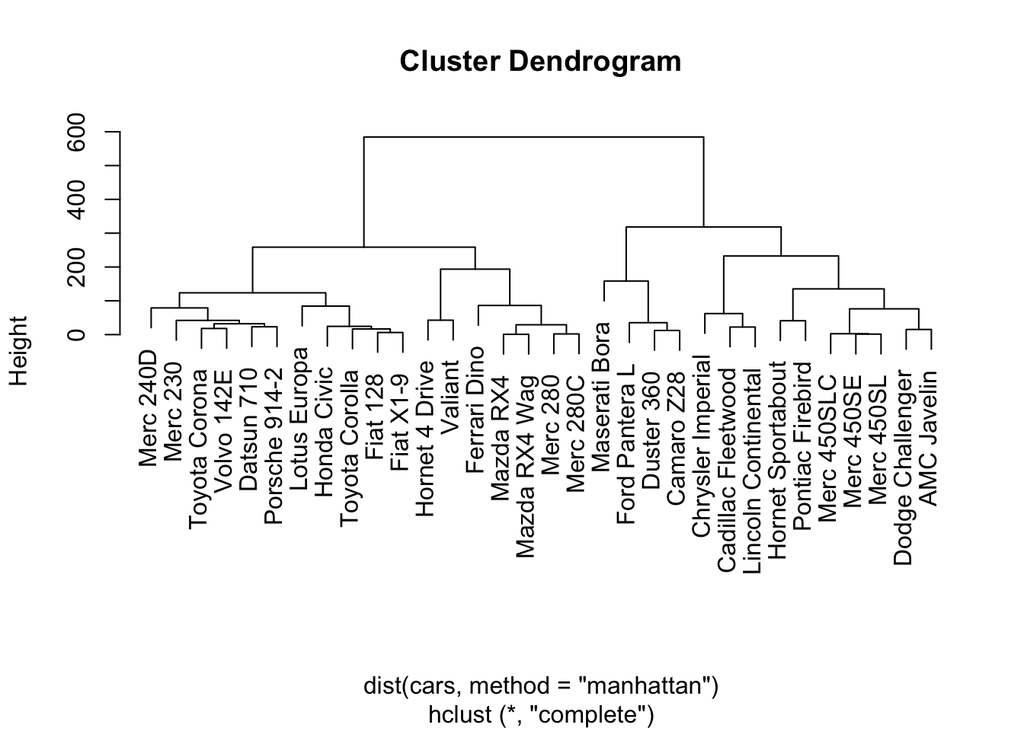

```r
manhattan_clusters <- hclust(dist(cars, method = "manhattan"))
plot(manhattan_clusters)
```

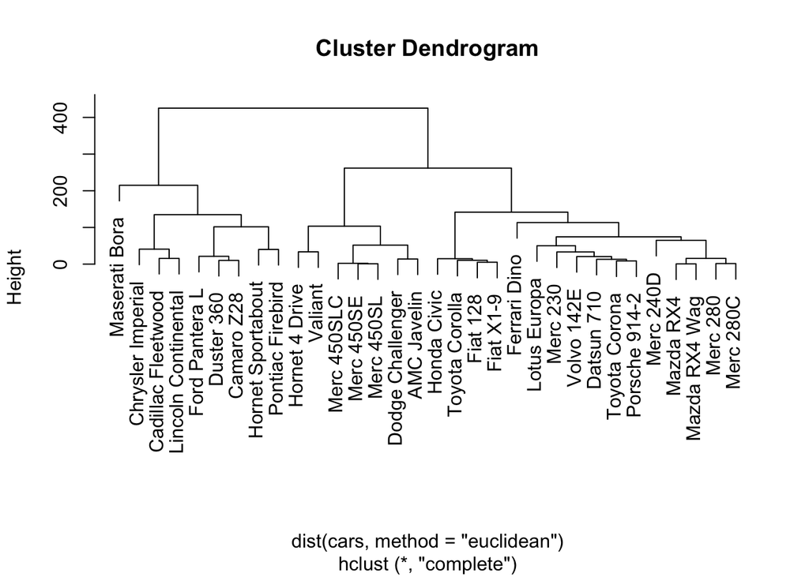

```r
euclidean_clusters <- hclust(dist(cars, method = "euclidean"))
plot(euclidean_clusters)
```

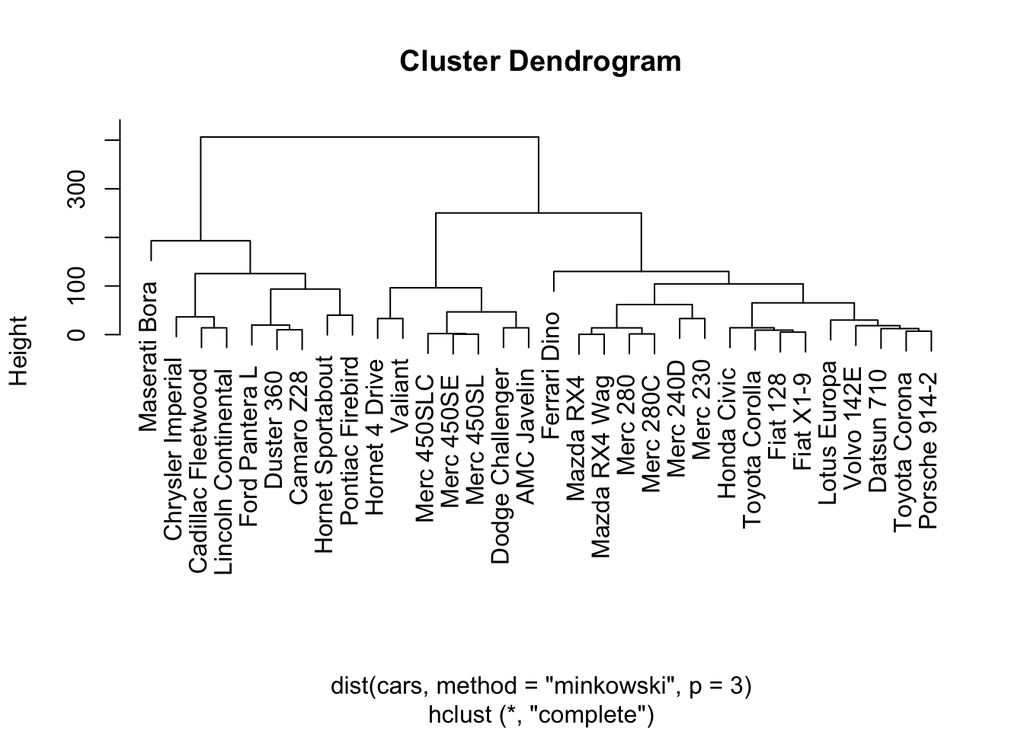

```r
minkowski_clusters <- hclust(dist(cars, method = "minkowski", p=3))
plot(minkowski_clusters)
```

All 3 distance measures give similar but not exactly the same results. The euclidean and minkowski models are more similar than either of those are to the manhattan model however. This makes sense since the calculations and numeric values for the euclidean and minkowski distances are very similar as well.

## Ex. 4

### Load the well-known Fisher’s `iris` flower data set that consists of 150 samples for three species (50 samples each species). The four measures or features are the lengths and widths of sepals and petals. Use kNN clustering to analyze this `iris` data set by selecting 120 samples for training and 30 samples for testing.

```r
set.seed(42)
index <- createDataPartition(iris$Species, p = 0.80, list = FALSE)
train <- iris[index, ]
test <- iris[-index, ]

knn_iris <- train(Species ~ ., data = train,
                 method = "knn")
knn_iris
```

```
## k-Nearest Neighbors
##
## 120 samples
##   4 predictor
##   3 classes: 'setosa', 'versicolor', 'virginica'
##
## No pre-processing
## Resampling: Bootstrapped (25 reps)
## Summary of sample sizes: 120, 120, 120, 120, 120, 120, ...
## Resampling results across tuning parameters:
##
##   k  Accuracy  Kappa
##   5  0.9710    0.9560
##   7  0.9755    0.9627
##   9  0.9743    0.9610
##
## Accuracy was used to select the optimal model using the largest value.
## The final value used for the model was k = 7.
```

```r
pred_iris <- predict(knn_iris, newdata = test)
confusionMatrix(pred_iris, test$Species)
```

```
## Confusion Matrix and Statistics
##
##             Reference
## Prediction   setosa versicolor virginica
##   setosa         10          0         0
##   versicolor      0          9         1
##   virginica       0          1         9
##
## Overall Statistics
##
##                Accuracy : 0.933
##                  95% CI : (0.779, 0.992)
##     No Information Rate : 0.333
##     P-Value [Acc > NIR] : 0.00000000000875
##
##                   Kappa : 0.9
##
##  Mcnemar's Test P-Value : NA
##
## Statistics by Class:
##
##                      Class: setosa Class: versicolor Class: virginica
## Sensitivity                  1.000             0.900            0.900
## Specificity                  1.000             0.950            0.950
## Pos Pred Value               1.000             0.900            0.900
## Neg Pred Value               1.000             0.950            0.950
## Prevalence                   0.333             0.333            0.333
## Detection Rate               0.333             0.300            0.300
## Detection Prevalence         0.333             0.333            0.333
## Balanced Accuracy            1.000             0.925            0.925
```

## Ex. 5

### Use the `iris` data set to carry out k-means clustering. Compare the results to the actual classes and estimate the clustering accuracy.

```r
set.seed(42)
kmeans_iris <- kmeans(iris[,c(1:4)], centers = 3, nstart = 25)
kmeans_iris
```

```
## K-means clustering with 3 clusters of sizes 50, 62, 38
##
## Cluster means:
##   Sepal.Length Sepal.Width Petal.Length Petal.Width
## 1        5.006       3.428        1.462       0.246
## 2        5.902       2.748        4.394       1.434
## 3        6.850       3.074        5.742       2.071
##
## Clustering vector:
##   [1] 1 1 1 1 1 1 1 1 1 1 1 1 1 1 1 1 1 1 1 1 1 1 1 1 1 1 1 1 1 1 1 1 1 1 1 1 1
##  [38] 1 1 1 1 1 1 1 1 1 1 1 1 1 2 2 3 2 2 2 2 2 2 2 2 2 2 2 2 2 2 2 2 2 2 2 2 2
##  [75] 2 2 2 3 2 2 2 2 2 2 2 2 2 2 2 2 2 2 2 2 2 2 2 2 2 2 3 2 3 3 3 3 2 3 3 3 3
## [112] 3 3 2 2 3 3 3 3 2 3 2 3 2 3 3 2 2 3 3 3 3 3 2 3 3 3 3 2 3 3 3 2 3 3 3 2 3
## [149] 3 2
##
## Within cluster sum of squares by cluster:
## [1] 15.15 39.82 23.88
##  (between_SS / total_SS =  88.4 %)
##
## Available components:
##
## [1] "cluster"      "centers"      "totss"        "withinss"     "tot.withinss"
## [6] "betweenss"    "size"         "iter"         "ifault"
```

```r
conf_mat <- table(kmeans_iris$cluster, iris$Species)
conf_mat
```

```
##
##     setosa versicolor virginica
##   1     50          0         0
##   2      0         48        14
##   3      0          2        36
```

```r
accuracy <- sum(diag(conf_mat))/sum(conf_mat)
accuracy
```

```
## [1] 0.8933
```